# Análisis base de datos completa

Daniel Miranda, Julio Iturra, Anaís Herrera y Kevin Carrasco

26-01-2021

```r
knitr::opts_chunk$set(warning = FALSE,
                      message = FALSE,
                      error = TRUE)
options(scipen=999)
```

```r
pacman::p_load(stargazer, ggplot2, sjmisc, car, sjlabelled, haven, cowplot,
               summarytools, kableExtra, corrplot, coefplot, ltm, polycor,
               psych, lme4, ppcor, texreg, skimr, gtools, bda, lmerTest, Matrix, extrafont, sessioninfo,sjPlot, dplyr)

##sessionInfo()
#R version 4.0.2 (2020-06-22)
#Platform: x86_64-w64-mingw32/x64 (64-bit)
#Running under: Windows 10 x64 (build 19042)

#Matrix products: default

#locale:
#[1] LC_COLLATE=Spanish_Chile.1252  LC_CTYPE=Spanish_Chile.1252    LC_MONETARY=Spanish_Chile.1252 LC_NUMERIC=C                   LC_TIME=Spanish_Chile.1252

#attached base packages:
#[1] stats     graphics  grDevices utils     datasets  methods   base

#other attached packages:
#[1] sessioninfo_1.1.1  dplyr_1.0.2        skimr_2.1.2        texreg_1.37.5      ppcor_1.1          lme4_1.1-26        Matrix_1.3-2       psych_2.0.12
#[9] ltm_1.1-1          polycor_0.7-10     msm_1.6.8          MASS_7.3-53        coefplot_1.2.7     corrplot_0.84      kableExtra_1.3.1   summarytools_0.9.8
#[17] sjPlot_2.8.7       cowplot_1.1.1      haven_2.3.1        sjlabelled_1.1.7   car_3.0-10         carData_3.0-4      sjmisc_2.8.6       ggplot2_3.3.3
#[25] stargazer_5.2.2


# Cargar base
load("../input/data-proc/data.rda")
```

# Descriptivos

```r
data$igualdad.est <- set_label(x = data$igualdad.est,label = "Actitudes del estudiante hacia la igualdad de género")
data$esp_publico.est <- set_label(x = data$esp_publico.est,label = "Actitudes del estudiante hacia la distribución igualitaria de roles en la esfera pública")
data$esp_privado.est <- set_label(x = data$esp_privado.est,label = "Actitudes del estudiante hacia la distribución igualitaria de roles en la esfera privada")
data$igualdad.pad <- set_label(x = data$igualdad.pad,label = "Actitudes del apoderado hacia la igualdad de género")
data$esp_publico.pad <- set_label(x = data$esp_publico.pad,label = "Actitudes del apoderado hacia la distribución igualitaria de roles en la esfera pública")
data$esp_privado.pad <- set_label(x = data$esp_privado.pad,label = "Actitudes del apoderado hacia la distribución igualitaria de roles en la esfera privada")
data$Sexo <- set_label(x = data$Sexo,label = "Sexo del estudiante")
data$Educacion <- set_label(x = data$Educacion,label = "Nivel educacional apoderado/a") # Etiquetar variable
data$Libros_apod_rec <- set_label(x = data$Libros_apod_rec,label = "Cantidad de libros en el hogar")
data$quintiles_ingresos_pc_factor <- set_label(x = data$quintiles_ingresos_pc_factor, label = "Ingresos per cápita del hogar en quintiles")
data$ap_discusion <- set_label(x = data$ap_discusion,label = "Percepción individual sobre la apertura a la discusión en el aula")
data$mean_discusion <- set_label(x = data$mean_discusion,label = "Percepción promedio del curso sobre la apertura a la discusión en el aula")
data$num_fem <- set_label(x = data$num_fem,label = "Proporción de niñas en el aula")
data$dependencia <- set_label(x=data$dependencia, label = "Dependencia administrativa de la escuela")
data$REGION <- set_label(x=data$REGION, label = "Región")
data$c_civic <- set_label(x = data$c_civic, label = "Conocimiento cívico conceptual")

descr <-
  data %>% select(
    igualdad.est,
    esp_publico.est,
    esp_privado.est,
    Sexo,
    ap_discusion,
    mean_discusion,
    num_fem,
    RBD,
    igualdad.pad,
    esp_publico.pad,
    esp_privado.pad,
    Educacion,
    Libros_apod_rec,
    quintiles_ingresos_pc_factor,
    dependencia,
    REGION,
    c_civic
  ) %>% ungroup()
st_css()
```

```r
print(dfSummary(descr,
               plain.ascii = FALSE,
               style = "grid",
               tmp.img.dir = "/tmp",
               graph.magnif = 0.75,
               headings = F,  # encabezado
               varnumbers = F, # num variable
               labels.col = T, # etiquetas
               na.col = T,    # missing
               graph.col = T, # plot
               valid.col = T, # n valido
               # col.widths = c(5,5,10,10,10,10)
               ),
     method = "render")
```

| **Variable** | **Label** | **Stats / Values** | **Freqs (% of Valid)** | **Graph** | **Valid** | **Missing** |
| --- | --- | --- | --- | --- | --- | --- |
| igualdad.est [numeric] | Actitudes del estudiante hacia la igualdad de género | Mean (sd) : 0 (0.5) min < med < max: -2.3 < 0.3 < 0.3 IQR (CV) : 0.5 (2451315) | 634 distinct values |  | 1635 (100.0%) | 0 (0.0%) |
| esp_publico.est [numeric] | Actitudes del estudiante hacia la distribución igualitaria de roles en la esfera pública | Mean (sd) : 0 (0.5) min < med < max: -2 < 0.2 < 0.5 IQR (CV) : 0.9 (1577289) | 634 distinct values |  | 1635 (100.0%) | 0 (0.0%) |
| esp_privado.est [numeric] | Actitudes del estudiante hacia la distribución igualitaria de roles en la esfera privada | Mean (sd) : 0 (0.6) min < med < max: -2.1 < 0.2 < 0.6 IQR (CV) : 1 (1645467) | 634 distinct values |  | 1635 (100.0%) | 0 (0.0%) |
| Sexo [factor] | Sexo del estudiante | 1. Niño 2. Niña | 834 ( 52.9% ) 743 ( 47.1% ) |  | 1577 (96.5%) | 58 (3.5%) |
| ap_discusion [numeric] | Percepción individual sobre la apertura a la discusión en el aula | Mean (sd) : 0 (0.6) min < med < max: -2.2 < 0 < 1.6 IQR (CV) : 0.8 (-2363200977374342144) | 1106 distinct values |  | 1490 (91.1%) | 145 (8.9%) |
| mean_discusion [numeric] | Percepción promedio del curso sobre la apertura a la discusión en el aula | Mean (sd) : 0 (0.3) min < med < max: -0.7 < 0 < 0.9 IQR (CV) : 0.4 (-201143210483705376) | 64 distinct values |  | 1635 (100.0%) | 0 (0.0%) |
| num_fem [numeric] | Proporción de niñas en el aula | Mean (sd) : 0.5 (0.2) min < med < max: 0 < 0.5 < 1 IQR (CV) : 0.2 (0.4) | 47 distinct values |  | 1635 (100.0%) | 0 (0.0%) |
| RBD [haven_labelled, vctrs_vctr, double] | RBD RBD | Mean (sd) : 15286.5 (10407.5) min < med < max: 218 < 12868 < 31421 IQR (CV) : 16973 (0.7) | 64 distinct values |  | 1635 (100.0%) | 0 (0.0%) |
| igualdad.pad [numeric] | Actitudes del apoderado hacia la igualdad de género | Mean (sd) : 0 (0.4) min < med < max: -2 < 0.2 < 0.2 IQR (CV) : 0.3 (364.3) | 306 distinct values |  | 713 (43.6%) | 922 (56.4%) |
| esp_publico.pad [numeric] | Actitudes del apoderado hacia la distribución igualitaria de roles en la esfera pública | Mean (sd) : 0 (0.4) min < med < max: -1.8 < 0.1 < 0.4 IQR (CV) : 0.7 (1508.3) | 306 distinct values |  | 713 (43.6%) | 922 (56.4%) |
| esp_privado.pad [numeric] | Actitudes del apoderado hacia la distribución igualitaria de roles en la esfera privada | Mean (sd) : 0 (0.5) min < med < max: -2 < 0.1 < 0.4 IQR (CV) : 0.7 (1449.1) | 306 distinct values |  | 713 (43.6%) | 922 (56.4%) |
| Educacion [factor] | Nivel educacional apoderado/a | 1. 8vo básico o menos 2. Educación Media 3. Educación Téc.Superior 4. Universidad o Posgrado | 77 ( 11.3% ) 302 ( 44.2% ) 177 ( 25.9% ) 127 ( 18.6% ) |  | 683 (41.8%) | 952 (58.2%) |
| Libros_apod_rec [factor] | Cantidad de libros en el hogar | 1. Entre 0 y 10 libros 2. Entre 11 y 25 libros 3. Entre 26 y 100 libros 4. Más de 100 libros | 133 ( 19.4% ) 198 ( 28.9% ) 240 ( 35.0% ) 114 ( 16.6% ) |  | 685 (41.9%) | 950 (58.1%) |
| quintiles_ingresos_pc_factor [factor] | Ingresos per cápita del hogar en quintiles | 1. Quintil 1 2. Quintil 2 3. Quintil 3 4. Quintil 4 5. Quintil 5 6. Ns/Nr | 111 ( 15.5% ) 116 ( 16.2% ) 114 ( 15.9% ) 114 ( 15.9% ) 108 ( 15.1% ) 153 ( 21.4% ) |  | 716 (43.8%) | 919 (56.2%) |
| dependencia [factor] | Dependencia administrativa de la escuela | 1. Municipal 2. Part. Subvencionado 3. Part. Pagado | 605 ( 37.0% ) 780 ( 47.7% ) 250 ( 15.3% ) |  | 1635 (100.0%) | 0 (0.0%) |
| REGION [factor] | Región | 1. Región de Antofagasta 2. Región del Maule 3. Región Metropolitana | 407 ( 24.9% ) 354 ( 21.7% ) 874 ( 53.5% ) |  | 1635 (100.0%) | 0 (0.0%) |
| c_civic [numeric] | Conocimiento cívico conceptual | Mean (sd) : 4.7 (2.2) min < med < max: 0 < 5 < 8 IQR (CV) : 3 (0.5) | 0 : 45 ( 2.8% ) 1 : 104 ( 6.4% ) 2 : 154 ( 9.4% ) 3 : 188 ( 11.5% ) 4 : 246 ( 15.0% ) 5 : 206 ( 12.6% ) 6 : 289 ( 17.7% ) 7 : 233 ( 14.3% ) 8 : 170 ( 10.4% ) |  | 1635 (100.0%) | 0 (0.0%) |

Generated by summarytools 0.9.8 ([R](https://www.r-project.org/) version 4.0.2)  
2021-05-14

## Indicadores igualdad de género

### Estudiantes

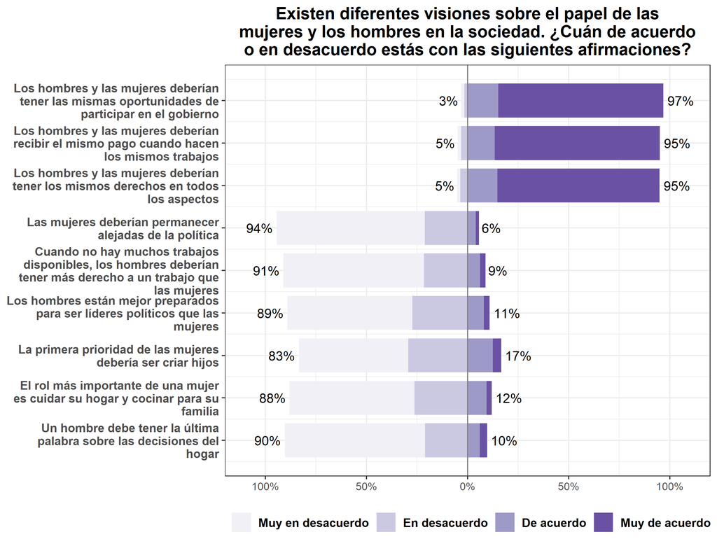

### Apoderados

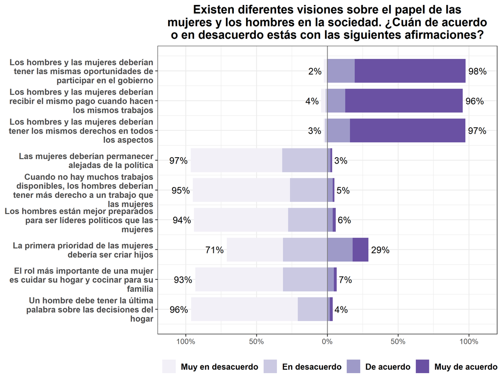

# Bivariados: Correlaciones

## Igualdad de género estudiantes

### Indicadores

```r
png("../output/cor_indicadores_ig_est.png",width=600,height=600)
corrplot.mixed(cor(dplyr::select(data,Igualdad1_rec.est, Igualdad5_rec.est, Igualdad7_rec.est, Igualdad3_rec.est, Igualdad4_rec.est, Igualdad6_rec.est, Igualdad2_rec.est, Igualdad8_rec.est, Igualdad9_rec.est),
                   use = "na.or.complete", method="spearman"))

dev.off()
```

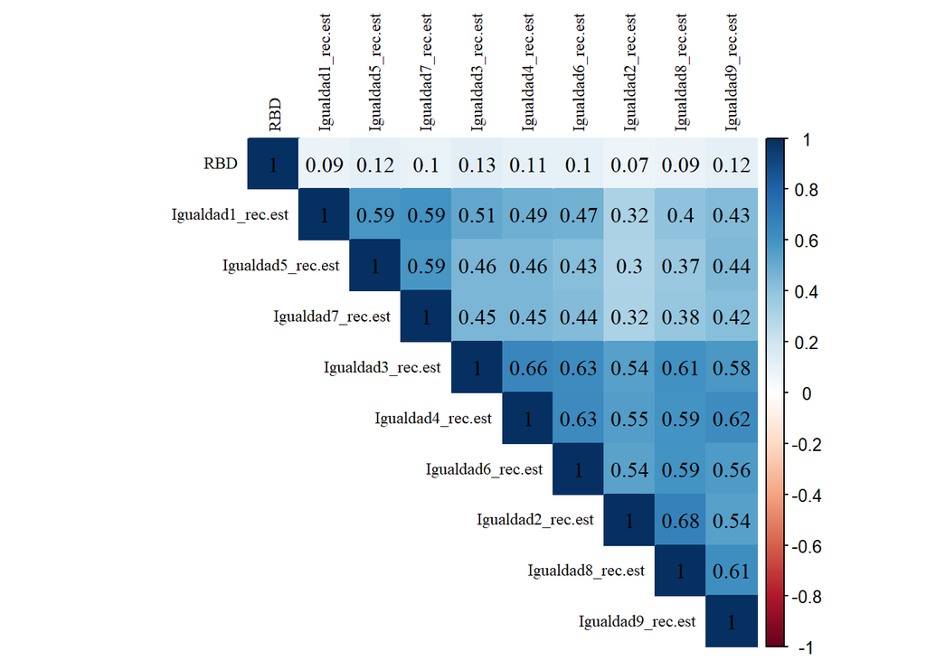

```r
#png("../output/cor_indicadores_ig_est.png",width=600,height=400)
windowsFonts(A = windowsFont("Times New Roman"))
cormat <- cor(dplyr::select(data,Igualdad1_rec.est, Igualdad5_rec.est, Igualdad7_rec.est, Igualdad3_rec.est, Igualdad4_rec.est, Igualdad6_rec.est, Igualdad2_rec.est, Igualdad8_rec.est, Igualdad9_rec.est), use = "na.or.complete", method="spearman")
#rownames(cormat) <-c(
 #   "A. Iguales oportunidades de participar en el gobierno",
  #  "B. Hombres y mujeres deberían recibir el mismo pago",
   # "C. Hombres y mujeres deberían tener los mismos derechos",
    #"D. Mujeres deberían permanecer alejadas de la política",
    #"E. Hombres deberían tener más derecho a un trabajo",
    #"F. Hombres están más preparados para ser líderes políticos",
    #"G. Primera prioridad de las mujeres es criar hijos",
    #"H. El rol de una mujer es cuidar su hogar y familia",
    #"I. Hombres deben tener la última palabra sobre el hogar")
#colnames(cormat) <-c("(A)", "(B)","(C)","(D)","(E)", "(F)","(G)","(H)","(I)")
corrplot(
cormat,
  method = "color",
  type = "upper",
  tl.col = "black",
  addCoef.col = "black",
  diag = TRUE,
  family = "A",
  number.font = 6,
  tl.cex =0.75,
  number.cex = 1)
```

### Puntuaciones factoriales

```r
png("../output/cor_punt_fact_ig_est.png",width=600,height=600)
corrplot.mixed(cor(dplyr::select(data, igualdad.est, esp_publico.est, esp_privado.est),
                   use = "na.or.complete"))
dev.off()
```

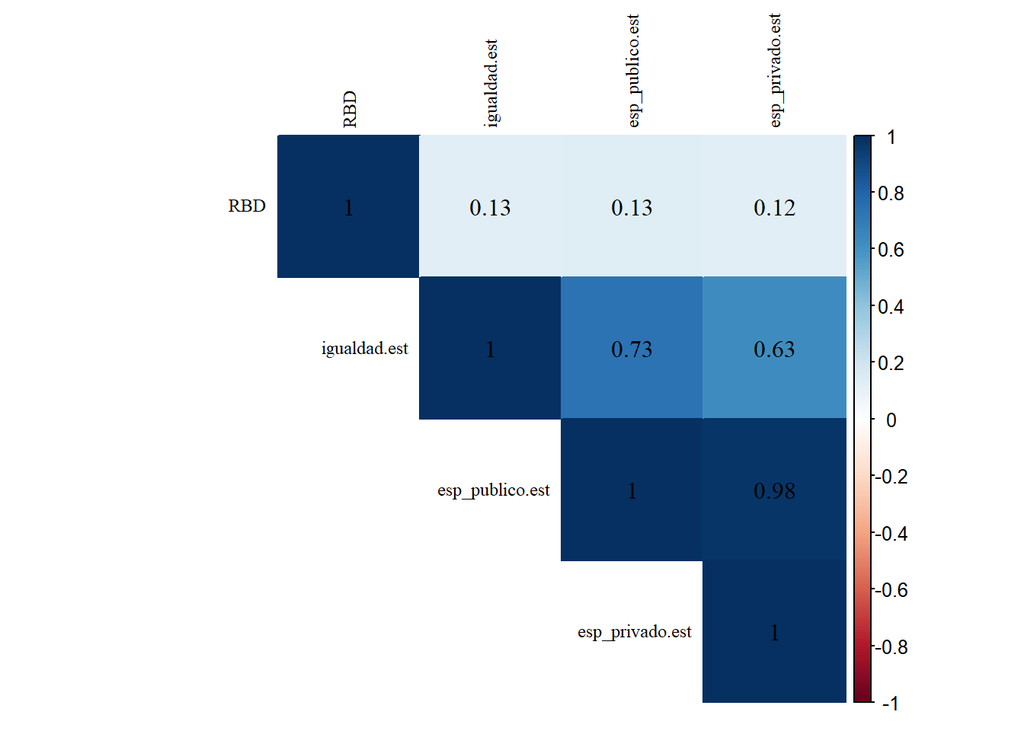

```r
windowsFonts(A = windowsFont("Times New Roman"))
cormat <- cor(dplyr::select(data, igualdad.est, esp_publico.est, esp_privado.est),
                   use = "na.or.complete")

#rownames(cormat) <-c(
 #   "A. Igualdad de derechos en general",
  #  "B. Supremacía masculina en el espacio publico",
   # "C. Supremacía masculina en el espacio privado")
#colnames(cormat) <-c("(A)", "(B)","(C)")
corrplot(
cormat,
  method = "color",
  type = "upper",
  tl.col = "black",
  addCoef.col = "black",
  diag = TRUE,
  family = "A",
  number.font = 6,
  tl.cex =0.75,
  number.cex = 1)
```

### Sexo

Se estimaron correlaciones biseriales. A continuación aparecen los valores de las correlaciones para cada dimensión y más adelante se presentan los mismos resultados ordenados en una tabla.

#### Igualdad de derechos y oportunidades

```r
# level = 2 es la categoría a utilizar, en este caso mujer (2)
biserial.cor(data$igualdad.est,data$Sexo, use = c("complete.obs"), level = 2)
```

```
## [1] 0.1644155
```

#### Distribución igualitaria en el espacio público

```r
biserial.cor(data$esp_publico.est,data$Sexo, use = c("complete.obs"), level = 2)
```

```
## [1] 0.2089993
```

#### Distribución igualitaria en el espacio privado

```r
biserial.cor(data$esp_privado.est,data$Sexo, use = c("complete.obs"), level = 2)
```

```
## [1] 0.2070701
```

#### Tabla de correlaciones biseriales

[output not shown]

### Recursos de la familia

```r
data$Educacion. <-as.numeric(data$Educacion)
data$Libros_apod_rec. <-as.numeric(data$Libros_apod_rec)

png("../output/cor_ig_est_recursos.png",width=600,height=600)
corrplot.mixed(cor(dplyr::select(data, igualdad.est, esp_publico.est, esp_privado.est, Educacion., Libros_apod_rec., ingresos_tramos),
                   use = "na.or.complete"))
dev.off()
```

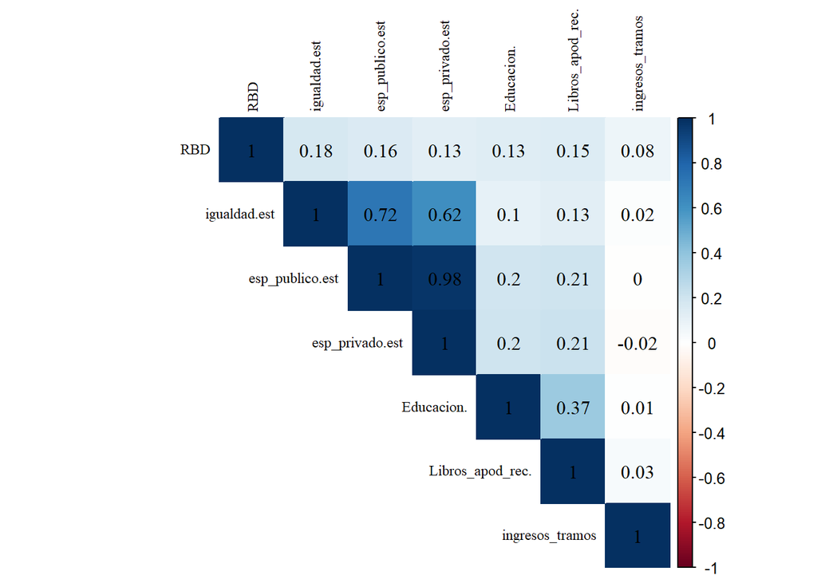

```r
windowsFonts(A = windowsFont("Times New Roman"))
cormat <- cor(dplyr::select(data, igualdad.est, esp_publico.est, esp_privado.est, Educacion., Libros_apod_rec., ingresos_tramos),
                   use = "na.or.complete")

corrplot(
cormat,
  method = "color",
  type = "upper",
  tl.col = "black",
  addCoef.col = "black",
  diag = TRUE,
  family = "A",
  number.font = 6,
  tl.cex =0.75,
  number.cex = 1)
```

### Igualdad de género apoderados

```r
png("../output/cor_fact_ig_est_apod.png",width=600,height=600)
corrplot.mixed(cor(dplyr::select(data, igualdad.est, esp_publico.est, esp_privado.est, igualdad.pad, esp_publico.pad, esp_privado.pad),
                   use = "na.or.complete"))
dev.off()
```

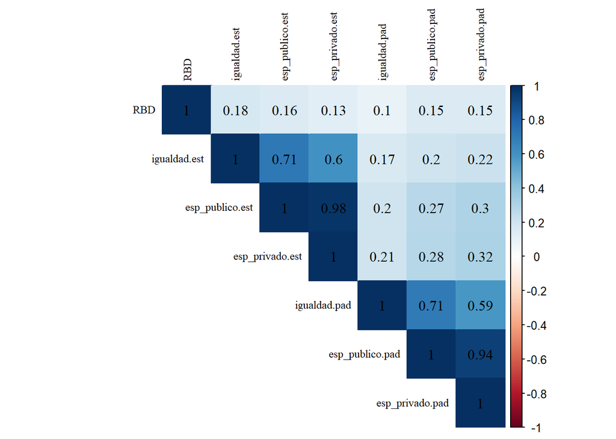

```r
windowsFonts(A = windowsFont("Times New Roman"))
cormat <- cor(dplyr::select(data, igualdad.est, esp_publico.est, esp_privado.est, igualdad.pad, esp_publico.pad, esp_privado.pad),
                   use = "na.or.complete")

corrplot(
cormat,
  method = "color",
  type = "upper",
  tl.col = "black",
  addCoef.col = "black",
  diag = TRUE,
  family = "A",
  number.font = 6,
  tl.cex =0.75,
  number.cex = 1)
```

### Apertura a la discusion en el aula y proporción de niñas

```r
png("../output/cor_ig_est_escuela.png",width=600,height=600)
corrplot.mixed(cor(dplyr::select(data, igualdad.est, esp_publico.est, esp_privado.est, ap_discusion, mean_discusion, num_fem),
                   use = "na.or.complete"))
dev.off()
```

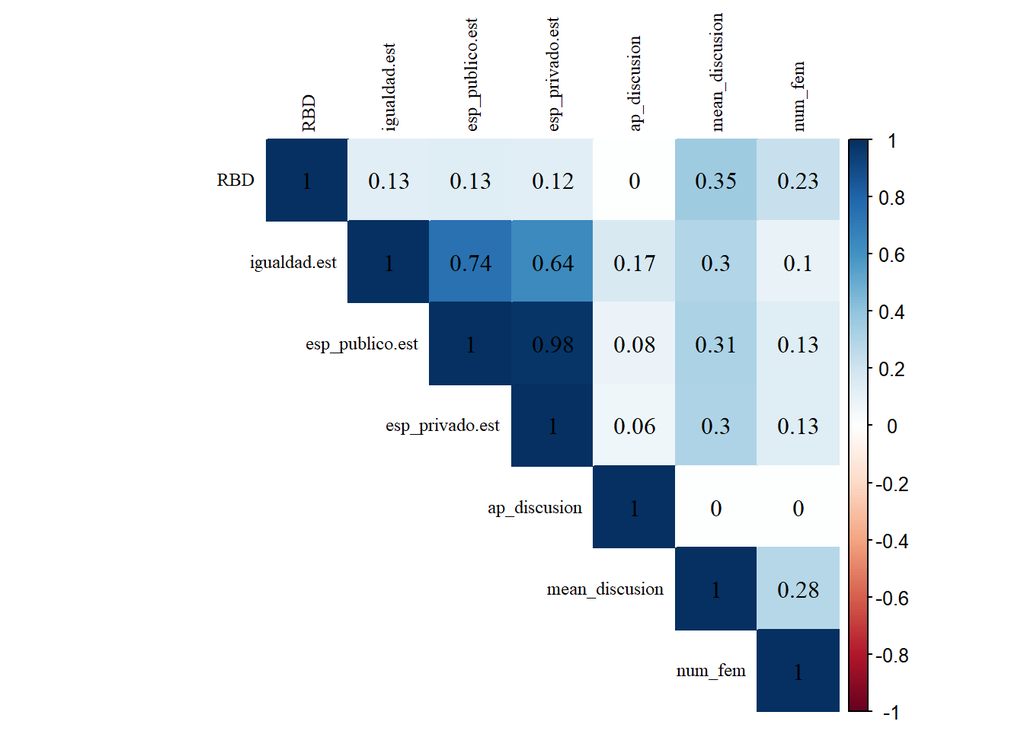

```r
windowsFonts(A = windowsFont("Times New Roman"))
cormat <- cor(dplyr::select(data, igualdad.est, esp_publico.est, esp_privado.est, ap_discusion, mean_discusion, num_fem),
                   use = "na.or.complete")

corrplot(
cormat,
  method = "color",
  type = "upper",
  tl.col = "black",
  addCoef.col = "black",
  diag = TRUE,
  family = "A",
  number.font = 6,
  tl.cex =0.75,
  number.cex = 1)
```

## Igualdad de género apoderados

### Indicadores

```r
png("../output/cor_indicadores_ig_apod.png",width=600,height=600)
corrplot.mixed(cor(dplyr::select(data,Igualdad1_rec.pad, Igualdad5_rec.pad, Igualdad7_rec.pad, Igualdad3_rec.pad, Igualdad4_rec.pad, Igualdad6_rec.pad, Igualdad2_rec.pad, Igualdad8_rec.pad, Igualdad9_rec.pad),
                   use = "na.or.complete", method="spearman"))
dev.off()
```

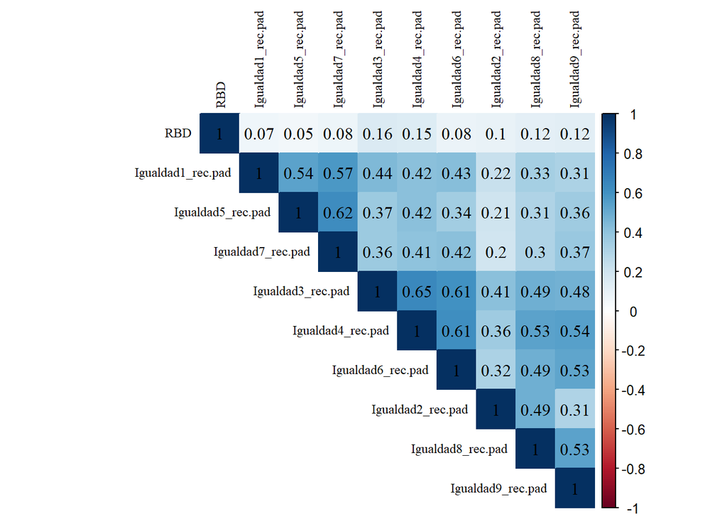

```r
windowsFonts(A = windowsFont("Times New Roman"))
cormat <- cor(dplyr::select(data,Igualdad1_rec.pad, Igualdad5_rec.pad, Igualdad7_rec.pad, Igualdad3_rec.pad, Igualdad4_rec.pad, Igualdad6_rec.pad, Igualdad2_rec.pad, Igualdad8_rec.pad, Igualdad9_rec.pad),
                   use = "na.or.complete", method="spearman")

corrplot(
cormat,
  method = "color",
  type = "upper",
  tl.col = "black",
  addCoef.col = "black",
  diag = TRUE,
  family = "A",
  number.font = 6,
  tl.cex =0.75,
  number.cex = 1)
```

### Puntuaciones factoriales

```r
png("../output/cor_punt_fact_ig_apod.png",width=600,height=600)
corrplot.mixed(cor(dplyr::select(data, igualdad.pad, esp_publico.pad, esp_privado.pad),
                   use = "na.or.complete"))
dev.off()
```

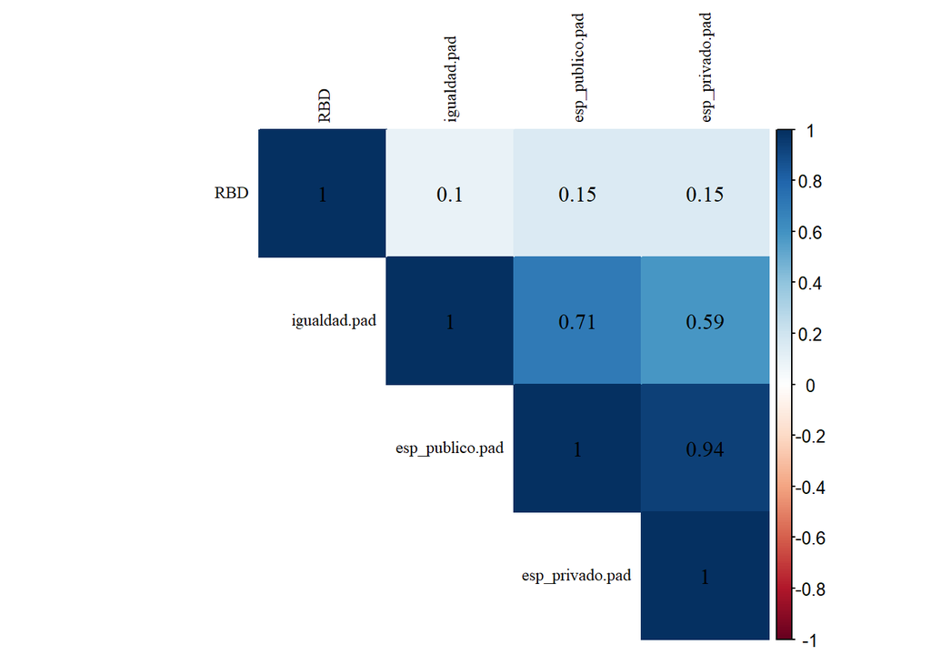

```r
windowsFonts(A = windowsFont("Times New Roman"))
cormat <- cor(dplyr::select(data,igualdad.pad, esp_publico.pad, esp_privado.pad),
                   use = "na.or.complete")

corrplot(
cormat,
  method = "color",
  type = "upper",
  tl.col = "black",
  addCoef.col = "black",
  diag = TRUE,
  family = "A",
  number.font = 6,
  tl.cex =0.75,
  number.cex = 1)
```

### Recursos de la familia

```r
png("../output/cor_ig_apod_recursos.png",width=600,height=600)
corrplot.mixed(cor(dplyr::select(data, igualdad.pad, esp_publico.pad, esp_privado.pad, Educacion., Libros_apod_rec., ingresos_tramos),
                   use = "na.or.complete"))
dev.off()
```

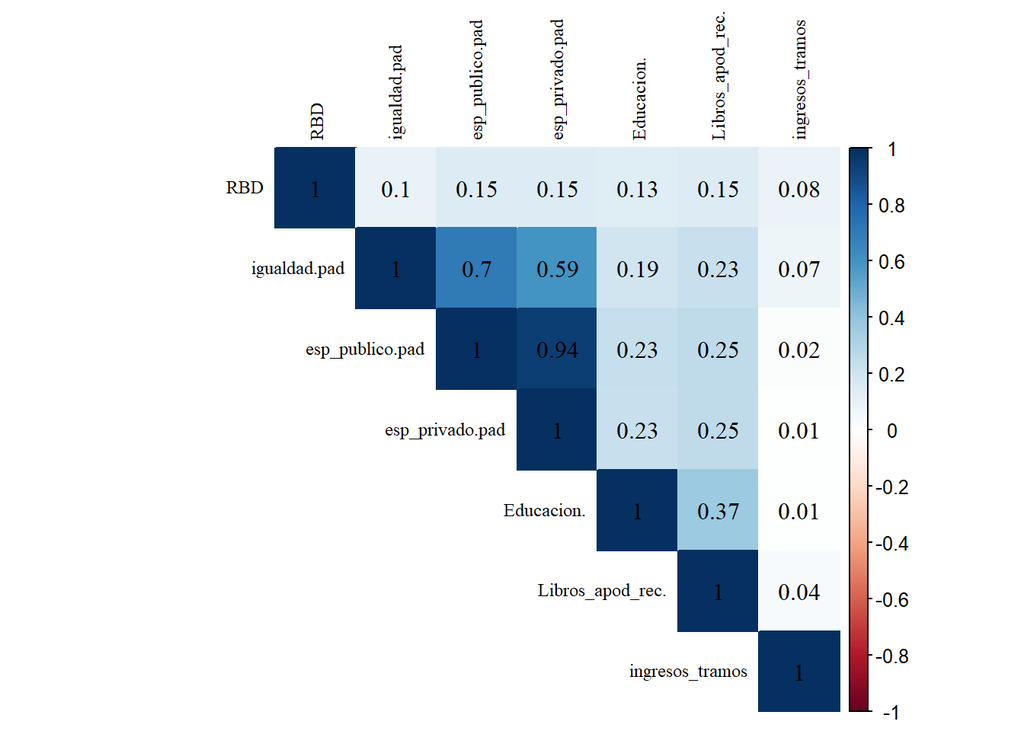

```r
windowsFonts(A = windowsFont("Times New Roman"))
cormat <- cor(dplyr::select(data, igualdad.pad, esp_publico.pad, esp_privado.pad, Educacion., Libros_apod_rec., ingresos_tramos),
                   use = "na.or.complete")

corrplot(
cormat,
  method = "color",
  type = "upper",
  tl.col = "black",
  addCoef.col = "black",
  diag = TRUE,
  family = "A",
  number.font = 6,
  tl.cex =0.75,
  number.cex = 1)
```

# Modelos de regresión

## Modelo nulo

```r
data$RBD <- as.factor(data$RBD)

reg0_igualdad <- lme4::lmer(igualdad.est ~ 1 + (1 | RBD), data=data)
reg0_pub <- lme4::lmer(esp_publico.est ~ 1 + (1 | RBD), data=data)
reg0_priv <- lme4::lmer(esp_privado.est ~ 1 + (1 | RBD), data=data)

#stargazer::stargazer(reg0_igualdad, reg0_pub, reg0_priv,
 # column.labels=c("Igualdad","Espacio público", "Espacio privado"),
  #type ='text')

#screenreg(list(reg0_igualdad, reg0_pub, reg0_priv))
```

```r
htmlreg(list(reg0_igualdad,reg0_pub, reg0_priv), custom.model.names = c("Actitudes del estudiante hacia la igualdad de derechos y oportunidades", "Actitudes del estudiante hacia la distribución igualitaria de roles en la esfera pública", "Actitudes del estudiante hacia la distribución igualitaria de roles en la esfera privada"), custom.note = "$***p <$ 0.001, $**p <$ 0.01, $*p <$ 0.05",  custom.coef.names = c("Intercepto"))
```

Statistical models

|  | Actitudes del estudiante hacia la igualdad de derechos y oportunidades | Actitudes del estudiante hacia la distribución igualitaria de roles en la esfera pública | Actitudes del estudiante hacia la distribución igualitaria de roles en la esfera privada |
| --- | --- | --- | --- |
| Intercepto | -0.03 | -0.03 | -0.03 |
|  | (0.03) | (0.03) | (0.04) |
| AIC | 2159.67 | 2435.91 | 2938.97 |
| BIC | 2175.87 | 2452.11 | 2955.16 |
| Log Likelihood | -1076.84 | -1214.96 | -1466.48 |
| Num. obs. | 1635 | 1635 | 1635 |
| Num. groups: RBD | 64 | 64 | 64 |
| Var: RBD (Intercept) | 0.04 | 0.06 | 0.08 |
| Var: Residual | 0.20 | 0.24 | 0.33 |

$***p <$ 0.001, $**p <$ 0.01, $*p <$ 0.05

### Correlación intra-clase

#### Igualdad de derechos y oportunidades

```r
reghelper::ICC(reg0_igualdad)
```

```
## [1] 0.1636024
```

#### Distribución igualitaria en el espacio público

```r
reghelper::ICC(reg0_pub)
```

```
## [1] 0.2006519
```

#### Distribución igualitaria en el espacio privada

```r
reghelper::ICC(reg0_priv)
```

```
## [1] 0.1891497
```

## Modelos de regresión

```r
reg_igualdad <- lmer(igualdad.est ~ 1 + Sexo + factor(Educacion) + factor(Libros_apod_rec) + factor(quintiles_ingresos_pc_factor) + igualdad.pad + ap_discusion + mean_discusion + num_fem + factor(dependencia) + factor(REGION) + c_civic + (1 | RBD), data=data)
reg_esp.pub <- lmer(esp_publico.est ~ 1 + Sexo + factor(Educacion) + factor(Libros_apod_rec) + factor(quintiles_ingresos_pc_factor) + esp_publico.pad + ap_discusion + mean_discusion + num_fem + factor(dependencia) + factor(REGION) + c_civic + (1 | RBD), data=data)
reg_esp.priv <- lmer(esp_privado.est ~ 1 + Sexo + factor(Educacion) + factor(Libros_apod_rec) + factor(quintiles_ingresos_pc_factor) + esp_privado.pad + ap_discusion + mean_discusion + num_fem + factor(dependencia) + factor(REGION) + c_civic + (1 | RBD), data=data)
#screenreg(list(reg_igualdad,reg_esp.pub,reg_esp.priv))
```

### Hipótesis 1.

*H1: Las niñas presentarán actitudes más positivas hacia la igualdad de género que los niños.*

```r
htmlreg(list(reg_igualdad,reg_esp.pub,reg_esp.priv), custom.model.names = c("Actitudes del estudiante hacia la igualdad de derechos y oportunidades", "Actitudes del estudiante hacia la distribución igualitaria de roles en la esfera pública", "Actitudes del estudiante hacia la distribución igualitaria de roles en la esfera privada"), omit.coef = "(Educacion)|(Libros_apod_rec)|(quintiles_ingresos_pc_factor)|(igualdad.pad)|(esp_publico.pad)|(esp_privado.pad)|(ap_discusion)|(mean_discusion)|(num_fem)|(dependencia)|(REGION)|(c_civic)", custom.note = "$***p <$ 0.001, $**p <$ 0.01, $*p <$ 0.05 <br> Todos los modelos están controlados por el resto de las variables analizadas, la dependencia administrativa de la escuela, la región y el nivel de conocimiento cívico del estudiante.",  custom.coef.names = c("Intercepto", "Sexo<br> <i>(Ref. Niño)</i>"))
```

Statistical models

|  | Actitudes del estudiante hacia la igualdad de derechos y oportunidades | Actitudes del estudiante hacia la distribución igualitaria de roles en la esfera pública | Actitudes del estudiante hacia la distribución igualitaria de roles en la esfera privada |
| --- | --- | --- | --- |
| Intercepto | -0.33*** | -0.59*** | -0.65*** |
|  | (0.10) | (0.11) | (0.12) |
| Sexo *(Ref. Niño)* | 0.08* | 0.15*** | 0.17*** |
|  | (0.03) | (0.04) | (0.04) |
| AIC | 598.61 | 799.11 | 981.31 |
| BIC | 705.27 | 905.77 | 1087.97 |
| Log Likelihood | -275.31 | -375.56 | -466.65 |
| Num. obs. | 629 | 629 | 629 |
| Num. groups: RBD | 60 | 60 | 60 |
| Var: RBD (Intercept) | 0.01 | 0.01 | 0.01 |
| Var: Residual | 0.12 | 0.16 | 0.22 |

$***p <$ 0.001, $**p <$ 0.01, $*p <$ 0.05 Todos los modelos están controlados por el resto de las variables analizadas, la dependencia administrativa de la escuela, la región y el nivel de conocimiento cívico del estudiante.

### Hipótesis 2.

*H2: Estudiantes que provienen de familias con mayores recursos socioeconómicos presentarán actitudes más positivas hacia la igualdad de género.*

#### Educación

```r
htmlreg(list(reg_igualdad,reg_esp.pub,reg_esp.priv), custom.model.names = c("Actitudes del estudiante hacia la igualdad de derechos y oportunidades", "Actitudes del estudiante hacia la distribución igualitaria de roles en la esfera pública", "Actitudes del estudiante hacia la distribución igualitaria de roles en la esfera privada"), omit.coef = "(Sexo)|(Libros_apod_rec)|(quintiles_ingresos_pc_factor)|(igualdad.pad)|(esp_publico.pad)|(esp_privado.pad)|(ap_discusion)|(mean_discusion)|(num_fem)|(dependencia)|(REGION)|(c_civic)", custom.note = "$***p <$ 0.001, $**p <$ 0.01, $*p <$ 0.05 <br> Todos los modelos están controlados por el resto de las variables analizadas, la dependencia administrativa de la escuela, la región y el nivel de conocimiento cívico del estudiante.",  custom.coef.names = c("Intercepto", "Educación Media <br> <i>(Ref. 8vo básico o menos)</i>", "Educación Técnica Superior (IP o CFT)", "Una carrera en la Universidad o estudios de Posgrado"))
```

Statistical models

|  | Actitudes del estudiante hacia la igualdad de derechos y oportunidades | Actitudes del estudiante hacia la distribución igualitaria de roles en la esfera pública | Actitudes del estudiante hacia la distribución igualitaria de roles en la esfera privada |
| --- | --- | --- | --- |
| Intercepto | -0.33*** | -0.59*** | -0.65*** |
|  | (0.10) | (0.11) | (0.12) |
| Educación Media *(Ref. 8vo básico o menos)* | -0.01 | -0.02 | -0.03 |
|  | (0.05) | (0.06) | (0.07) |
| Educación Técnica Superior (IP o CFT) | -0.00 | -0.02 | -0.03 |
|  | (0.05) | (0.06) | (0.08) |
| Una carrera en la Universidad o estudios de Posgrado | -0.00 | 0.01 | 0.01 |
|  | (0.06) | (0.08) | (0.09) |
| AIC | 598.61 | 799.11 | 981.31 |
| BIC | 705.27 | 905.77 | 1087.97 |
| Log Likelihood | -275.31 | -375.56 | -466.65 |
| Num. obs. | 629 | 629 | 629 |
| Num. groups: RBD | 60 | 60 | 60 |
| Var: RBD (Intercept) | 0.01 | 0.01 | 0.01 |
| Var: Residual | 0.12 | 0.16 | 0.22 |

$***p <$ 0.001, $**p <$ 0.01, $*p <$ 0.05 Todos los modelos están controlados por el resto de las variables analizadas, la dependencia administrativa de la escuela, la región y el nivel de conocimiento cívico del estudiante.

#### Cantidad de libros en el hogar

```r
htmlreg(list(reg_igualdad,reg_esp.pub,reg_esp.priv), custom.model.names = c("Actitudes del estudiante hacia la igualdad de derechos y oportunidades", "Actitudes del estudiante hacia la distribución igualitaria de roles en la esfera pública", "Actitudes del estudiante hacia la distribución igualitaria de roles en la esfera privada"), omit.coef = "(Sexo)|(Educacion)|(quintiles_ingresos_pc_factor)|(igualdad.pad)|(esp_publico.pad)|(esp_privado.pad)|(ap_discusion)|(mean_discusion)|(num_fem)|(dependencia)|(REGION)|(c_civic)", custom.note = "$***p <$ 0.001, $**p <$ 0.01, $*p <$ 0.05 <br> Todos los modelos están controlados por el resto de las variables analizadas, la dependencia administrativa de la escuela, la región y el nivel de conocimiento cívico del estudiante.",  custom.coef.names = c("Intercepto", "Entre 11 y 25 libros <br> <i>(Ref. Entre 0 y 10 libros)</i>", "Entre 26 y 100 libros", "Más de 100 libros"))
```

Statistical models

|  | Actitudes del estudiante hacia la igualdad de derechos y oportunidades | Actitudes del estudiante hacia la distribución igualitaria de roles en la esfera pública | Actitudes del estudiante hacia la distribución igualitaria de roles en la esfera privada |
| --- | --- | --- | --- |
| Intercepto | -0.33*** | -0.59*** | -0.65*** |
|  | (0.10) | (0.11) | (0.12) |
| Entre 11 y 25 libros *(Ref. Entre 0 y 10 libros)* | 0.09* | 0.04 | 0.02 |
|  | (0.04) | (0.05) | (0.06) |
| Entre 26 y 100 libros | 0.04 | 0.05 | 0.05 |
|  | (0.04) | (0.05) | (0.06) |
| Más de 100 libros | 0.03 | 0.02 | 0.02 |
|  | (0.05) | (0.06) | (0.07) |
| AIC | 598.61 | 799.11 | 981.31 |
| BIC | 705.27 | 905.77 | 1087.97 |
| Log Likelihood | -275.31 | -375.56 | -466.65 |
| Num. obs. | 629 | 629 | 629 |
| Num. groups: RBD | 60 | 60 | 60 |
| Var: RBD (Intercept) | 0.01 | 0.01 | 0.01 |
| Var: Residual | 0.12 | 0.16 | 0.22 |

$***p <$ 0.001, $**p <$ 0.01, $*p <$ 0.05 Todos los modelos están controlados por el resto de las variables analizadas, la dependencia administrativa de la escuela, la región y el nivel de conocimiento cívico del estudiante.

#### Ingresos

```r
htmlreg(list(reg_igualdad,reg_esp.pub,reg_esp.priv), custom.model.names = c("Actitudes del estudiante hacia la igualdad de derechos y oportunidades", "Actitudes del estudiante hacia la distribución igualitaria de roles en la esfera pública", "Actitudes del estudiante hacia la distribución igualitaria de roles en la esfera privada"), omit.coef = "(Sexo)|(Educacion)|(Libros_apod_rec)|(igualdad.pad)|(esp_publico.pad)|(esp_privado.pad)|(ap_discusion)|(mean_discusion)|(num_fem)|(dependencia)|(REGION)|(c_civic)", custom.note = "$***p <$ 0.001, $**p <$ 0.01, $*p <$ 0.05 <br> Todos los modelos están controlados por el resto de las variables analizadas, la dependencia administrativa de la escuela, la región y el nivel de conocimiento cívico del estudiante.",  custom.coef.names = c("Intercepto", "Quintil 2 <br> <i>(Ref. Quintil 1)</i>", "Quintil 3", "Quintil 4", "Quintil 5", "No sabe / No responde"))
```

Statistical models

|  | Actitudes del estudiante hacia la igualdad de derechos y oportunidades | Actitudes del estudiante hacia la distribución igualitaria de roles en la esfera pública | Actitudes del estudiante hacia la distribución igualitaria de roles en la esfera privada |
| --- | --- | --- | --- |
| Intercepto | -0.33*** | -0.59*** | -0.65*** |
|  | (0.10) | (0.11) | (0.12) |
| Quintil 2 *(Ref. Quintil 1)* | 0.07 | 0.15** | 0.18** |
|  | (0.05) | (0.06) | (0.07) |
| Quintil 3 | 0.11* | 0.15* | 0.20** |
|  | (0.05) | (0.06) | (0.07) |
| Quintil 4 | 0.03 | 0.12* | 0.16* |
|  | (0.05) | (0.06) | (0.07) |
| Quintil 5 | 0.09 | 0.12 | 0.15 |
|  | (0.06) | (0.07) | (0.08) |
| No sabe / No responde | 0.09 | 0.13* | 0.13 |
|  | (0.05) | (0.06) | (0.07) |
| AIC | 598.61 | 799.11 | 981.31 |
| BIC | 705.27 | 905.77 | 1087.97 |
| Log Likelihood | -275.31 | -375.56 | -466.65 |
| Num. obs. | 629 | 629 | 629 |
| Num. groups: RBD | 60 | 60 | 60 |
| Var: RBD (Intercept) | 0.01 | 0.01 | 0.01 |
| Var: Residual | 0.12 | 0.16 | 0.22 |

$***p <$ 0.001, $**p <$ 0.01, $*p <$ 0.05 Todos los modelos están controlados por el resto de las variables analizadas, la dependencia administrativa de la escuela, la región y el nivel de conocimiento cívico del estudiante.

### Hipótesis 3.

*H3: Estudiantes con apoderados que poseen actitudes más positivas hacia la igualdad de género presentarán actitudes más positivas hacia la igualdad de género.*

```r
htmlreg(list(reg_igualdad,reg_esp.pub,reg_esp.priv), custom.model.names = c("Actitudes del estudiante hacia la igualdad de derechos y oportunidades", "Actitudes del estudiante hacia la distribución igualitaria de roles en la esfera pública", "Actitudes del estudiante hacia la distribución igualitaria de roles en la esfera privada"), omit.coef = "(Sexo)|(Educacion)|(Libros_apod_rec)|(quintiles_ingresos_pc_factor)|(ap_discusion)|(mean_discusion)|(num_fem)|(dependencia)|(REGION)|(c_civic)", custom.note = "$***p <$ 0.001, $**p <$ 0.01, $*p <$ 0.05 <br> Todos los modelos están controlados por el resto de las variables analizadas, la dependencia administrativa de la escuela, la región y el nivel de conocimiento cívico del estudiante.",  custom.coef.names = c("Intercepto", "Actitudes del apoderado hacia la igualdad de derechos y oportunidades", "Actitudes del apoderado hacia la distribución igualitaria de roles en la esfera pública", "Actitudes del apoderado hacia la distribución igualitaria de roles en la esfera privada"))
```

Statistical models

|  | Actitudes del estudiante hacia la igualdad de derechos y oportunidades | Actitudes del estudiante hacia la distribución igualitaria de roles en la esfera pública | Actitudes del estudiante hacia la distribución igualitaria de roles en la esfera privada |
| --- | --- | --- | --- |
| Intercepto | -0.33*** | -0.59*** | -0.65*** |
|  | (0.10) | (0.11) | (0.12) |
| Actitudes del apoderado hacia la igualdad de derechos y oportunidades | 0.09* |  |  |
|  | (0.04) |  |  |
| Actitudes del apoderado hacia la distribución igualitaria de roles en la esfera pública |  | 0.16*** |  |
|  |  | (0.04) |  |
| Actitudes del apoderado hacia la distribución igualitaria de roles en la esfera privada |  |  | 0.24*** |
|  |  |  | (0.05) |
| AIC | 598.61 | 799.11 | 981.31 |
| BIC | 705.27 | 905.77 | 1087.97 |
| Log Likelihood | -275.31 | -375.56 | -466.65 |
| Num. obs. | 629 | 629 | 629 |
| Num. groups: RBD | 60 | 60 | 60 |
| Var: RBD (Intercept) | 0.01 | 0.01 | 0.01 |
| Var: Residual | 0.12 | 0.16 | 0.22 |

$***p <$ 0.001, $**p <$ 0.01, $*p <$ 0.05 Todos los modelos están controlados por el resto de las variables analizadas, la dependencia administrativa de la escuela, la región y el nivel de conocimiento cívico del estudiante.

### Hipótesis 4.

*H4: Apoderados con mayores recursos socioeconómicos presentarán actitudes más positivas hacia la igualdad de género.*

```r
h4_igualdad.apod <- lmer(igualdad.pad ~ 1 + factor(Educacion) + factor(Libros_apod_rec) + factor(quintiles_ingresos_pc_factor) + factor(REGION) + (1 | RBD), data=data)
h4_esp_pub.apod <- lmer(esp_publico.pad ~ 1 + factor(Educacion) + factor(Libros_apod_rec) + factor(quintiles_ingresos_pc_factor) + factor(REGION) + (1 | RBD), data=data)
h4_esp_priv.apod <- lmer(esp_privado.pad ~ 1 + factor(Educacion) + factor(Libros_apod_rec) + factor(quintiles_ingresos_pc_factor) + factor(REGION) + (1 | RBD), data=data)
#screenreg(list(h4_igualdad.apod,h4_esp_pub.apod,h4_esp_priv.apod))
```

#### Educación

```r
htmlreg(list(h4_igualdad.apod,h4_esp_pub.apod,h4_esp_priv.apod), custom.model.names = c("Actitudes del apoderado hacia  la igualdad de derechos  y oportunidades", "Actitudes del apoderado hacia  la distribución igualitaria de roles en la esfera pública", "Actitudes del apoderado hacia  la distribución igualitaria de roles en la esfera privada"), omit.coef = "(Libros_apod_rec)|(quintiles_ingresos_pc_factor)|(REGION)", custom.note = "$***p <$ 0.001, $**p <$ 0.01, $*p <$ 0.05 <br> Los modelos están controlados por la cantidad de libros en el hogar, los ingresos mensuales de los miembros del hogar y la región en que residen.",  custom.coef.names = c("Intercepto", "Educación Media <br> <i>(Ref. 8vo básico o menos)</i>", "Educación Técnica Superior (IP o CFT)", "Una carrera en la Universidad o  estudios de Posgrado"))
```

Statistical models

|  | Actitudes del apoderado hacia la igualdad de derechos y oportunidades | Actitudes del apoderado hacia la distribución igualitaria de roles en la esfera pública | Actitudes del apoderado hacia la distribución igualitaria de roles en la esfera privada |
| --- | --- | --- | --- |
| Intercepto | -0.25*** | -0.30*** | -0.36*** |
|  | (0.06) | (0.07) | (0.08) |
| Educación Media *(Ref. 8vo básico o menos)* | 0.13** | 0.13* | 0.13* |
|  | (0.04) | (0.05) | (0.06) |
| Educación Técnica Superior (IP o CFT) | 0.15** | 0.20*** | 0.21*** |
|  | (0.05) | (0.06) | (0.06) |
| Una carrera en la Universidad o estudios de Posgrado | 0.16** | 0.24*** | 0.24*** |
|  | (0.06) | (0.07) | (0.07) |
| AIC | 518.46 | 779.40 | 823.02 |
| BIC | 590.72 | 851.66 | 895.28 |
| Log Likelihood | -243.23 | -373.70 | -395.51 |
| Num. obs. | 676 | 676 | 676 |
| Num. groups: RBD | 60 | 60 | 60 |
| Var: RBD (Intercept) | 0.00 | 0.01 | 0.01 |
| Var: Residual | 0.11 | 0.16 | 0.17 |

$***p <$ 0.001, $**p <$ 0.01, $*p <$ 0.05 Los modelos están controlados por la cantidad de libros en el hogar, los ingresos mensuales de los miembros del hogar y la región en que residen.

#### Cantidad de libros en el hogar

```r
htmlreg(list(h4_igualdad.apod,h4_esp_pub.apod,h4_esp_priv.apod), custom.model.names = c("Actitudes del apoderado hacia  la igualdad de derechos  y oportunidades", "Actitudes del apoderado hacia  la distribución igualitaria de roles en la esfera pública", "Actitudes del apoderado hacia  la distribución igualitaria de roles en la esfera privada"), omit.coef = "(Educacion)|(quintiles_ingresos_pc_factor)|(REGION)", custom.note = "$***p <$ 0.001, $**p <$ 0.01, $*p <$ 0.05 <br> Los modelos están controlados por el nivel educativo del apoderado, los ingresos mensuales de los miembros del hogar y la región en que residen.",  custom.coef.names = c("Intercepto", "Entre 11 y 25 libros <br> <i>(Ref. Entre 0 y 10 libros)</i>", "Entre 26 y 100 libros", "Más de 100 libros"))
```

Statistical models

|  | Actitudes del apoderado hacia la igualdad de derechos y oportunidades | Actitudes del apoderado hacia la distribución igualitaria de roles en la esfera pública | Actitudes del apoderado hacia la distribución igualitaria de roles en la esfera privada |
| --- | --- | --- | --- |
| Intercepto | -0.25*** | -0.30*** | -0.36*** |
|  | (0.06) | (0.07) | (0.08) |
| Entre 11 y 25 libros *(Ref. Entre 0 y 10 libros)* | 0.08* | 0.10* | 0.10* |
|  | (0.04) | (0.05) | (0.05) |
| Entre 26 y 100 libros | 0.13*** | 0.19*** | 0.21*** |
|  | (0.04) | (0.05) | (0.05) |
| Más de 100 libros | 0.19*** | 0.23*** | 0.22*** |
|  | (0.05) | (0.06) | (0.06) |
| AIC | 518.46 | 779.40 | 823.02 |
| BIC | 590.72 | 851.66 | 895.28 |
| Log Likelihood | -243.23 | -373.70 | -395.51 |
| Num. obs. | 676 | 676 | 676 |
| Num. groups: RBD | 60 | 60 | 60 |
| Var: RBD (Intercept) | 0.00 | 0.01 | 0.01 |
| Var: Residual | 0.11 | 0.16 | 0.17 |

$***p <$ 0.001, $**p <$ 0.01, $*p <$ 0.05 Los modelos están controlados por el nivel educativo del apoderado, los ingresos mensuales de los miembros del hogar y la región en que residen.

#### Ingresos

```r
htmlreg(list(h4_igualdad.apod,h4_esp_pub.apod,h4_esp_priv.apod), custom.model.names = c("Actitudes del apoderado hacia  la igualdad de derechos  y oportunidades", "Actitudes del apoderado hacia  la distribución igualitaria de roles en la esfera pública", "Actitudes del apoderado hacia  la distribución igualitaria de roles en la esfera privada"), omit.coef = "(Libros_apod_rec)|(Educacion)|(REGION)", custom.note = "$***p <$ 0.001, $**p <$ 0.01, $*p <$ 0.05 <br> Los modelos están controlados por el nivel educativo del apoderado, la cantidad de libros en el hogar y la región en que residen.",  custom.coef.names = c("Intercepto", "Quintil 2 <br> <i>(Ref. Quintil 1)</i>", "Quintil 3", "Quintil 4", "Quintil 5", "No sabe / No responde"))
```

Statistical models

|  | Actitudes del apoderado hacia la igualdad de derechos y oportunidades | Actitudes del apoderado hacia la distribución igualitaria de roles en la esfera pública | Actitudes del apoderado hacia la distribución igualitaria de roles en la esfera privada |
| --- | --- | --- | --- |
| Intercepto | -0.25*** | -0.30*** | -0.36*** |
|  | (0.06) | (0.07) | (0.08) |
| Quintil 2 *(Ref. Quintil 1)* | -0.06 | -0.07 | -0.06 |
|  | (0.05) | (0.06) | (0.06) |
| Quintil 3 | -0.05 | -0.04 | -0.03 |
|  | (0.05) | (0.06) | (0.06) |
| Quintil 4 | 0.04 | 0.01 | 0.00 |
|  | (0.05) | (0.06) | (0.06) |
| Quintil 5 | 0.00 | -0.03 | -0.01 |
|  | (0.05) | (0.06) | (0.07) |
| No sabe / No responde | 0.04 | -0.03 | -0.02 |
|  | (0.05) | (0.06) | (0.06) |
| AIC | 518.46 | 779.40 | 823.02 |
| BIC | 590.72 | 851.66 | 895.28 |
| Log Likelihood | -243.23 | -373.70 | -395.51 |
| Num. obs. | 676 | 676 | 676 |
| Num. groups: RBD | 60 | 60 | 60 |
| Var: RBD (Intercept) | 0.00 | 0.01 | 0.01 |
| Var: Residual | 0.11 | 0.16 | 0.17 |

$***p <$ 0.001, $**p <$ 0.01, $*p <$ 0.05 Los modelos están controlados por el nivel educativo del apoderado, la cantidad de libros en el hogar y la región en que residen.

#### Modelo H4 completo

```r
htmlreg(list(h4_igualdad.apod,h4_esp_pub.apod,h4_esp_priv.apod), custom.model.names = c("Actitudes del apoderado hacia  la igualdad de derechos  y oportunidades", "Actitudes del apoderado hacia  la distribución igualitaria de roles en la esfera pública", "Actitudes del apoderado hacia  la distribución igualitaria de roles en la esfera privada"), custom.note = "$***p <$ 0.001, $**p <$ 0.01, $*p <$ 0.05",  custom.coef.names = c("Intercepto", "Educación Media <br> <i>(Ref. 8vo básico o menos)</i>", "Educación Técnica Superior (IP o CFT)", "Una carrera en la Universidad o  estudios de Posgrado", "Entre 11 y 25 libros <br> <i>(Ref. Entre 0 y 10 libros)</i>", "Entre 26 y 100 libros", "Más de 100 libros", "Quintil 2 <br> <i>(Ref. Quintil 1)</i>", "Quintil 3", "Quintil 4", "Quintil 5", "No sabe / No responde", "Reg. del Maule <br> <i>(Ref. Reg. de Antofagasta)</i>", "Reg. Metropolitana"))
```

Statistical models

|  | Actitudes del apoderado hacia la igualdad de derechos y oportunidades | Actitudes del apoderado hacia la distribución igualitaria de roles en la esfera pública | Actitudes del apoderado hacia la distribución igualitaria de roles en la esfera privada |
| --- | --- | --- | --- |
| Intercepto | -0.25*** | -0.30*** | -0.36*** |
|  | (0.06) | (0.07) | (0.08) |
| Educación Media *(Ref. 8vo básico o menos)* | 0.13** | 0.13* | 0.13* |
|  | (0.04) | (0.05) | (0.06) |
| Educación Técnica Superior (IP o CFT) | 0.15** | 0.20*** | 0.21*** |
|  | (0.05) | (0.06) | (0.06) |
| Una carrera en la Universidad o estudios de Posgrado | 0.16** | 0.24*** | 0.24*** |
|  | (0.06) | (0.07) | (0.07) |
| Entre 11 y 25 libros *(Ref. Entre 0 y 10 libros)* | 0.08* | 0.10* | 0.10* |
|  | (0.04) | (0.05) | (0.05) |
| Entre 26 y 100 libros | 0.13*** | 0.19*** | 0.21*** |
|  | (0.04) | (0.05) | (0.05) |
| Más de 100 libros | 0.19*** | 0.23*** | 0.22*** |
|  | (0.05) | (0.06) | (0.06) |
| Quintil 2 *(Ref. Quintil 1)* | -0.06 | -0.07 | -0.06 |
|  | (0.05) | (0.06) | (0.06) |
| Quintil 3 | -0.05 | -0.04 | -0.03 |
|  | (0.05) | (0.06) | (0.06) |
| Quintil 4 | 0.04 | 0.01 | 0.00 |
|  | (0.05) | (0.06) | (0.06) |
| Quintil 5 | 0.00 | -0.03 | -0.01 |
|  | (0.05) | (0.06) | (0.07) |
| No sabe / No responde | 0.04 | -0.03 | -0.02 |
|  | (0.05) | (0.06) | (0.06) |
| Reg. del Maule *(Ref. Reg. de Antofagasta)* | -0.01 | -0.03 | 0.03 |
|  | (0.05) | (0.06) | (0.06) |
| Reg. Metropolitana | 0.06 | 0.11* | 0.16** |
|  | (0.04) | (0.05) | (0.06) |
| AIC | 518.46 | 779.40 | 823.02 |
| BIC | 590.72 | 851.66 | 895.28 |
| Log Likelihood | -243.23 | -373.70 | -395.51 |
| Num. obs. | 676 | 676 | 676 |
| Num. groups: RBD | 60 | 60 | 60 |
| Var: RBD (Intercept) | 0.00 | 0.01 | 0.01 |
| Var: Residual | 0.11 | 0.16 | 0.17 |

$***p <$ 0.001, $**p <$ 0.01, $*p <$ 0.05

### Hipótesis 5.

*H5: Las características de la escuela (proporción de niñas; apertura a la discusión en el aula) se asocian positivamente con las actitudes de los estudiantes hacia la igualdad de género.*

#### Apertura a la discusión en el aula

```r
htmlreg(list(reg_igualdad,reg_esp.pub,reg_esp.priv), custom.model.names = c("Actitudes del estudiante hacia  la igualdad de derechos  y oportunidades", "Actitudes del estudiante hacia  la distribución igualitaria de roles en la esfera pública", "Actitudes del estudiante hacia  la distribución igualitaria de roles en la esfera privada"), omit.coef = "(Sexo)|(Educacion)|(Libros_apod_rec)|(quintiles_ingresos_pc_factor)|(igualdad.pad)|(esp_publico.pad)|(esp_privado.pad)|(num_fem)|(dependencia)|(REGION)|(c_civic)", custom.note = "$***p <$ 0.001, $**p <$ 0.01, $*p <$ 0.05 <br> Todos los modelos están controlados por el resto de las variables analizadas, la dependencia administrativa de la escuela, la región y el nivel de conocimiento cívico del estudiante.",  custom.coef.names = c("Intercepto", "Percepción individual sobre la apertura  a la discusión en el aula", "Percepción general sobre la apertura  a la discusión en el aula"))
```

Statistical models

|  | Actitudes del estudiante hacia la igualdad de derechos y oportunidades | Actitudes del estudiante hacia la distribución igualitaria de roles en la esfera pública | Actitudes del estudiante hacia la distribución igualitaria de roles en la esfera privada |
| --- | --- | --- | --- |
| Intercepto | -0.33*** | -0.59*** | -0.65*** |
|  | (0.10) | (0.11) | (0.12) |
| Percepción individual sobre la apertura a la discusión en el aula | 0.12*** | 0.07* | 0.05 |
|  | (0.03) | (0.03) | (0.03) |
| Percepción general sobre la apertura a la discusión en el aula | 0.36*** | 0.34*** | 0.37*** |
|  | (0.09) | (0.09) | (0.10) |
| AIC | 598.61 | 799.11 | 981.31 |
| BIC | 705.27 | 905.77 | 1087.97 |
| Log Likelihood | -275.31 | -375.56 | -466.65 |
| Num. obs. | 629 | 629 | 629 |
| Num. groups: RBD | 60 | 60 | 60 |
| Var: RBD (Intercept) | 0.01 | 0.01 | 0.01 |
| Var: Residual | 0.12 | 0.16 | 0.22 |

$***p <$ 0.001, $**p <$ 0.01, $*p <$ 0.05 Todos los modelos están controlados por el resto de las variables analizadas, la dependencia administrativa de la escuela, la región y el nivel de conocimiento cívico del estudiante.

#### Proporción de niñas

```r
htmlreg(list(reg_igualdad,reg_esp.pub,reg_esp.priv), custom.model.names = c("Actitudes del estudiante hacia  la igualdad de derechos  y oportunidades", "Actitudes del estudiante hacia  la distribución igualitaria de roles en la esfera pública", "Actitudes del estudiante hacia  la distribución igualitaria de roles en la esfera privada"), omit.coef = "(Sexo)|(Educacion)|(Libros_apod_rec)|(quintiles_ingresos_pc_factor)|(igualdad.pad)|(esp_publico.pad)|(esp_privado.pad)|(ap_discusion)|(mean_discusion)|(dependencia)|(REGION)|(c_civic)", custom.note = "$***p <$ 0.001, $**p <$ 0.01, $*p <$ 0.05 <br> Todos los modelos están controlados por el resto de las variables analizadas, la dependencia administrativa de la escuela, la región y el nivel de conocimiento cívico del estudiante.",  custom.coef.names = c("Intercepto", "Proporción de niñas en el aula"))
```

Statistical models

|  | Actitudes del estudiante hacia la igualdad de derechos y oportunidades | Actitudes del estudiante hacia la distribución igualitaria de roles en la esfera pública | Actitudes del estudiante hacia la distribución igualitaria de roles en la esfera privada |
| --- | --- | --- | --- |
| Intercepto | -0.33*** | -0.59*** | -0.65*** |
|  | (0.10) | (0.11) | (0.12) |
| Proporción de niñas en el aula | 0.05 | -0.03 | -0.02 |
|  | (0.12) | (0.12) | (0.14) |
| AIC | 598.61 | 799.11 | 981.31 |
| BIC | 705.27 | 905.77 | 1087.97 |
| Log Likelihood | -275.31 | -375.56 | -466.65 |
| Num. obs. | 629 | 629 | 629 |
| Num. groups: RBD | 60 | 60 | 60 |
| Var: RBD (Intercept) | 0.01 | 0.01 | 0.01 |
| Var: Residual | 0.12 | 0.16 | 0.22 |

$***p <$ 0.001, $**p <$ 0.01, $*p <$ 0.05 Todos los modelos están controlados por el resto de las variables analizadas, la dependencia administrativa de la escuela, la región y el nivel de conocimiento cívico del estudiante.

### Pendientes fijas y aleatorias

#### Igualdad de género

```r
reg_igualdad_pf <- lmer(igualdad.est ~ 1 + Sexo + factor(Educacion) + factor(Libros_apod_rec) + factor(quintiles_ingresos_pc_factor) + igualdad.pad + ap_discusion + mean_discusion + num_fem + factor(dependencia) + factor(REGION) + c_civic + (1 | RBD), data=data)
# Educación
reg_igualdad_pa1 <- lmer(igualdad.est ~ 1 + Sexo + factor(Educacion) + factor(Libros_apod_rec) + factor(quintiles_ingresos_pc_factor) + igualdad.pad + ap_discusion + mean_discusion + num_fem + factor(dependencia) + factor(REGION) + c_civic + (1 + factor(Educacion) | RBD), data=data)
anova(reg_igualdad_pf,reg_igualdad_pa1) #no
```

```
## Data: data
## Models:
## reg_igualdad_pf: igualdad.est ~ 1 + Sexo + factor(Educacion) + factor(Libros_apod_rec) +
## reg_igualdad_pf:     factor(quintiles_ingresos_pc_factor) + igualdad.pad + ap_discusion +
## reg_igualdad_pf:     mean_discusion + num_fem + factor(dependencia) + factor(REGION) +
## reg_igualdad_pf:     c_civic + (1 | RBD)
## reg_igualdad_pa1: igualdad.est ~ 1 + Sexo + factor(Educacion) + factor(Libros_apod_rec) +
## reg_igualdad_pa1:     factor(quintiles_ingresos_pc_factor) + igualdad.pad + ap_discusion +
## reg_igualdad_pa1:     mean_discusion + num_fem + factor(dependencia) + factor(REGION) +
## reg_igualdad_pa1:     c_civic + (1 + factor(Educacion) | RBD)
##                  npar    AIC    BIC  logLik deviance  Chisq Df Pr(>Chisq)
## reg_igualdad_pf    24 496.77 603.43 -224.39   448.77
## reg_igualdad_pa1   33 508.01 654.67 -221.01   442.01 6.7615  9     0.6619
```

```r
# Libros
reg_igualdad_pa2 <- lmer(igualdad.est ~ 1 + Sexo + factor(Educacion) + factor(Libros_apod_rec) + factor(quintiles_ingresos_pc_factor) + igualdad.pad + ap_discusion + mean_discusion + num_fem + factor(dependencia) + factor(REGION) + c_civic + (1 + factor(Libros_apod_rec) | RBD), data=data)
anova(reg_igualdad_pf,reg_igualdad_pa2) #no
```

```
## Data: data
## Models:
## reg_igualdad_pf: igualdad.est ~ 1 + Sexo + factor(Educacion) + factor(Libros_apod_rec) +
## reg_igualdad_pf:     factor(quintiles_ingresos_pc_factor) + igualdad.pad + ap_discusion +
## reg_igualdad_pf:     mean_discusion + num_fem + factor(dependencia) + factor(REGION) +
## reg_igualdad_pf:     c_civic + (1 | RBD)
## reg_igualdad_pa2: igualdad.est ~ 1 + Sexo + factor(Educacion) + factor(Libros_apod_rec) +
## reg_igualdad_pa2:     factor(quintiles_ingresos_pc_factor) + igualdad.pad + ap_discusion +
## reg_igualdad_pa2:     mean_discusion + num_fem + factor(dependencia) + factor(REGION) +
## reg_igualdad_pa2:     c_civic + (1 + factor(Libros_apod_rec) | RBD)
##                  npar    AIC    BIC  logLik deviance Chisq Df Pr(>Chisq)
## reg_igualdad_pf    24 496.77 603.43 -224.39   448.77
## reg_igualdad_pa2   33 507.43 654.09 -220.72   441.43 7.344  9     0.6014
```

```r
# Ingresos
#reg_igualdad_pa3 <- lmer(igualdad.est ~ 1 + Sexo + factor(Educacion) + factor(Libros_apod_rec) + factor(quintiles_ingresos_pc_factor) + igualdad.pad + ap_discusion + mean_discusion + num_fem + factor(dependencia) + factor(REGION) + c_civic + (1 + factor(quintiles_ingresos_pc_factor) | RBD), data=data) ###no es posible estimar el modelo: "Error: number of observations (=627) <= number of random effects (=720) for term (1 + factor(ingresos_tramos) | RBD); the random-effects parameters and the residual variance (or scale parameter) are probably unidentifiable"
# Actitudes del apoderado
reg_igualdad_pa4 <- lmer(igualdad.est ~ 1 + Sexo + factor(Educacion) + factor(Libros_apod_rec) + factor(quintiles_ingresos_pc_factor) + igualdad.pad + ap_discusion + mean_discusion + num_fem + factor(dependencia) + factor(REGION) + c_civic + (1 + igualdad.pad | RBD), data=data)
anova(reg_igualdad_pf,reg_igualdad_pa4) #sí
```

```
## Data: data
## Models:
## reg_igualdad_pf: igualdad.est ~ 1 + Sexo + factor(Educacion) + factor(Libros_apod_rec) +
## reg_igualdad_pf:     factor(quintiles_ingresos_pc_factor) + igualdad.pad + ap_discusion +
## reg_igualdad_pf:     mean_discusion + num_fem + factor(dependencia) + factor(REGION) +
## reg_igualdad_pf:     c_civic + (1 | RBD)
## reg_igualdad_pa4: igualdad.est ~ 1 + Sexo + factor(Educacion) + factor(Libros_apod_rec) +
## reg_igualdad_pa4:     factor(quintiles_ingresos_pc_factor) + igualdad.pad + ap_discusion +
## reg_igualdad_pa4:     mean_discusion + num_fem + factor(dependencia) + factor(REGION) +
## reg_igualdad_pa4:     c_civic + (1 + igualdad.pad | RBD)
##                  npar    AIC    BIC  logLik deviance  Chisq Df Pr(>Chisq)
## reg_igualdad_pf    24 496.77 603.43 -224.39   448.77
## reg_igualdad_pa4   26 491.48 607.02 -219.74   439.48 9.2982  2    0.00957 **
## ---
## Signif. codes:  0 '***' 0.001 '**' 0.01 '*' 0.05 '.' 0.1 ' ' 1
```

```r
# Sexo
reg_igualdad_pa5 <- lmer(igualdad.est ~ 1 + Sexo + factor(Educacion) + factor(Libros_apod_rec) + factor(quintiles_ingresos_pc_factor) + igualdad.pad + ap_discusion + mean_discusion + num_fem + factor(dependencia) + factor(REGION) + c_civic + (1 + Sexo | RBD), data=data)
anova(reg_igualdad_pf,reg_igualdad_pa5) #sí
```

```
## Data: data
## Models:
## reg_igualdad_pf: igualdad.est ~ 1 + Sexo + factor(Educacion) + factor(Libros_apod_rec) +
## reg_igualdad_pf:     factor(quintiles_ingresos_pc_factor) + igualdad.pad + ap_discusion +
## reg_igualdad_pf:     mean_discusion + num_fem + factor(dependencia) + factor(REGION) +
## reg_igualdad_pf:     c_civic + (1 | RBD)
## reg_igualdad_pa5: igualdad.est ~ 1 + Sexo + factor(Educacion) + factor(Libros_apod_rec) +
## reg_igualdad_pa5:     factor(quintiles_ingresos_pc_factor) + igualdad.pad + ap_discusion +
## reg_igualdad_pa5:     mean_discusion + num_fem + factor(dependencia) + factor(REGION) +
## reg_igualdad_pa5:     c_civic + (1 + Sexo | RBD)
##                  npar    AIC    BIC  logLik deviance  Chisq Df Pr(>Chisq)
## reg_igualdad_pf    24 496.77 603.43 -224.39   448.77
## reg_igualdad_pa5   26 489.35 604.90 -218.68   437.35 11.421  2   0.003312 **
## ---
## Signif. codes:  0 '***' 0.001 '**' 0.01 '*' 0.05 '.' 0.1 ' ' 1
```

#### Espacio público

```r
reg_esp.pub_pf <- lmer(esp_publico.est ~ 1 + Sexo + factor(Educacion) + factor(Libros_apod_rec) + factor(quintiles_ingresos_pc_factor) + esp_publico.pad + ap_discusion + mean_discusion + num_fem + factor(dependencia) + factor(REGION) + c_civic + (1 | RBD), data=data)
# Educación
reg_esp.pub_pa1 <- lmer(esp_publico.est ~ 1 + Sexo + factor(Educacion) + factor(Libros_apod_rec) + factor(quintiles_ingresos_pc_factor) + esp_publico.pad + ap_discusion + mean_discusion + num_fem + factor(dependencia) + factor(REGION) + c_civic + (1 + factor(Educacion) | RBD), data=data)
anova(reg_esp.pub_pf,reg_esp.pub_pa1) #no
```

```
## Data: data
## Models:
## reg_esp.pub_pf: esp_publico.est ~ 1 + Sexo + factor(Educacion) + factor(Libros_apod_rec) +
## reg_esp.pub_pf:     factor(quintiles_ingresos_pc_factor) + esp_publico.pad +
## reg_esp.pub_pf:     ap_discusion + mean_discusion + num_fem + factor(dependencia) +
## reg_esp.pub_pf:     factor(REGION) + c_civic + (1 | RBD)
## reg_esp.pub_pa1: esp_publico.est ~ 1 + Sexo + factor(Educacion) + factor(Libros_apod_rec) +
## reg_esp.pub_pa1:     factor(quintiles_ingresos_pc_factor) + esp_publico.pad +
## reg_esp.pub_pa1:     ap_discusion + mean_discusion + num_fem + factor(dependencia) +
## reg_esp.pub_pa1:     factor(REGION) + c_civic + (1 + factor(Educacion) | RBD)
##                 npar    AIC    BIC  logLik deviance  Chisq Df Pr(>Chisq)
## reg_esp.pub_pf    24 702.59 809.25 -327.29   654.59
## reg_esp.pub_pa1   33 712.84 859.50 -323.42   646.84 7.7462  9     0.5599
```

```r
# Libros
reg_esp.pub_pa2 <- lmer(esp_publico.est ~ 1 + Sexo + factor(Educacion) + factor(Libros_apod_rec) + factor(quintiles_ingresos_pc_factor) + esp_publico.pad + ap_discusion + mean_discusion + num_fem + factor(dependencia) + factor(REGION) + c_civic + (1 + factor(Libros_apod_rec) | RBD), data=data)
anova(reg_esp.pub_pf,reg_esp.pub_pa2) #no
```

```
## Data: data
## Models:
## reg_esp.pub_pf: esp_publico.est ~ 1 + Sexo + factor(Educacion) + factor(Libros_apod_rec) +
## reg_esp.pub_pf:     factor(quintiles_ingresos_pc_factor) + esp_publico.pad +
## reg_esp.pub_pf:     ap_discusion + mean_discusion + num_fem + factor(dependencia) +
## reg_esp.pub_pf:     factor(REGION) + c_civic + (1 | RBD)
## reg_esp.pub_pa2: esp_publico.est ~ 1 + Sexo + factor(Educacion) + factor(Libros_apod_rec) +
## reg_esp.pub_pa2:     factor(quintiles_ingresos_pc_factor) + esp_publico.pad +
## reg_esp.pub_pa2:     ap_discusion + mean_discusion + num_fem + factor(dependencia) +
## reg_esp.pub_pa2:     factor(REGION) + c_civic + (1 + factor(Libros_apod_rec) |
## reg_esp.pub_pa2:     RBD)
##                 npar    AIC    BIC  logLik deviance  Chisq Df Pr(>Chisq)
## reg_esp.pub_pf    24 702.59 809.25 -327.29   654.59
## reg_esp.pub_pa2   33 713.45 860.11 -323.73   647.45 7.1324  9     0.6233
```

```r
# Ingresos
#reg_esp.pub_pa3 <- lmer(esp_publico.est ~ 1 + Sexo + factor(Educacion) + factor(Libros_apod_rec) + factor(quintiles_ingresos_pc_factor) + esp_publico.pad + ap_discusion + mean_discusion + num_fem + factor(dependencia) + factor(REGION) + c_civic + (1 + factor(quintiles_ingresos_pc_factor) | RBD), data=data) ###no es posible estimar el modelo: "Error: number of observations (=627) <= number of random effects (=720) for term (1 + factor(ingresos_tramos) | RBD); the random-effects parameters and the residual variance (or scale parameter) are probably unidentifiable"
# Actitudes del apoderado
reg_esp.pub_pa4 <- lmer(esp_publico.est ~ 1 + Sexo + factor(Educacion) + factor(Libros_apod_rec) + factor(quintiles_ingresos_pc_factor) + esp_publico.pad + ap_discusion + mean_discusion + num_fem + factor(dependencia) + factor(REGION) + c_civic + (1 + esp_publico.pad | RBD), data=data)
anova(reg_esp.pub_pf,reg_esp.pub_pa4) #sí
```

```
## Data: data
## Models:
## reg_esp.pub_pf: esp_publico.est ~ 1 + Sexo + factor(Educacion) + factor(Libros_apod_rec) +
## reg_esp.pub_pf:     factor(quintiles_ingresos_pc_factor) + esp_publico.pad +
## reg_esp.pub_pf:     ap_discusion + mean_discusion + num_fem + factor(dependencia) +
## reg_esp.pub_pf:     factor(REGION) + c_civic + (1 | RBD)
## reg_esp.pub_pa4: esp_publico.est ~ 1 + Sexo + factor(Educacion) + factor(Libros_apod_rec) +
## reg_esp.pub_pa4:     factor(quintiles_ingresos_pc_factor) + esp_publico.pad +
## reg_esp.pub_pa4:     ap_discusion + mean_discusion + num_fem + factor(dependencia) +
## reg_esp.pub_pa4:     factor(REGION) + c_civic + (1 + esp_publico.pad | RBD)
##                 npar    AIC    BIC  logLik deviance  Chisq Df Pr(>Chisq)
## reg_esp.pub_pf    24 702.59 809.25 -327.29   654.59
## reg_esp.pub_pa4   26 693.95 809.50 -320.98   641.95 12.636  2   0.001803 **
## ---
## Signif. codes:  0 '***' 0.001 '**' 0.01 '*' 0.05 '.' 0.1 ' ' 1
```

```r
# Sexo
reg_esp.pub_pa5 <- lmer(esp_publico.est ~ 1 + Sexo + factor(Educacion) + factor(Libros_apod_rec) + factor(quintiles_ingresos_pc_factor) + esp_publico.pad + ap_discusion + mean_discusion + num_fem + factor(dependencia) + factor(REGION) + c_civic + (1 + Sexo | RBD), data=data)
anova(reg_esp.pub_pf,reg_esp.pub_pa5) #no
```

```
## Data: data
## Models:
## reg_esp.pub_pf: esp_publico.est ~ 1 + Sexo + factor(Educacion) + factor(Libros_apod_rec) +
## reg_esp.pub_pf:     factor(quintiles_ingresos_pc_factor) + esp_publico.pad +
## reg_esp.pub_pf:     ap_discusion + mean_discusion + num_fem + factor(dependencia) +
## reg_esp.pub_pf:     factor(REGION) + c_civic + (1 | RBD)
## reg_esp.pub_pa5: esp_publico.est ~ 1 + Sexo + factor(Educacion) + factor(Libros_apod_rec) +
## reg_esp.pub_pa5:     factor(quintiles_ingresos_pc_factor) + esp_publico.pad +
## reg_esp.pub_pa5:     ap_discusion + mean_discusion + num_fem + factor(dependencia) +
## reg_esp.pub_pa5:     factor(REGION) + c_civic + (1 + Sexo | RBD)
##                 npar    AIC    BIC  logLik deviance  Chisq Df Pr(>Chisq)
## reg_esp.pub_pf    24 702.59 809.25 -327.29   654.59
## reg_esp.pub_pa5   26 704.39 819.93 -326.19   652.39 2.1988  2     0.3331
```

#### Espacio privado

```r
reg_esp.priv_pf <- lmer(esp_privado.est ~ 1 + Sexo + factor(Educacion) + factor(Libros_apod_rec) + factor(quintiles_ingresos_pc_factor) + esp_privado.pad + ap_discusion + mean_discusion + num_fem + factor(dependencia) + factor(REGION) + c_civic + (1 | RBD), data=data)
# Educación
reg_esp.priv_pa1 <- lmer(esp_privado.est ~ 1 + Sexo + factor(Educacion) + factor(Libros_apod_rec) + factor(quintiles_ingresos_pc_factor) + esp_privado.pad + ap_discusion + mean_discusion + num_fem + factor(dependencia) + factor(REGION) + c_civic + (1 + factor(Educacion) | RBD), data=data)
anova(reg_esp.priv_pf,reg_esp.priv_pa1) #no
```

```
## Data: data
## Models:
## reg_esp.priv_pf: esp_privado.est ~ 1 + Sexo + factor(Educacion) + factor(Libros_apod_rec) +
## reg_esp.priv_pf:     factor(quintiles_ingresos_pc_factor) + esp_privado.pad +
## reg_esp.priv_pf:     ap_discusion + mean_discusion + num_fem + factor(dependencia) +
## reg_esp.priv_pf:     factor(REGION) + c_civic + (1 | RBD)
## reg_esp.priv_pa1: esp_privado.est ~ 1 + Sexo + factor(Educacion) + factor(Libros_apod_rec) +
## reg_esp.priv_pa1:     factor(quintiles_ingresos_pc_factor) + esp_privado.pad +
## reg_esp.priv_pa1:     ap_discusion + mean_discusion + num_fem + factor(dependencia) +
## reg_esp.priv_pa1:     factor(REGION) + c_civic + (1 + factor(Educacion) | RBD)
##                  npar    AIC     BIC  logLik deviance  Chisq Df Pr(>Chisq)
## reg_esp.priv_pf    24 890.93  997.59 -421.47   842.93
## reg_esp.priv_pa1   33 902.36 1049.02 -418.18   836.36 6.5675  9      0.682
```

```r
# Libros
reg_esp.priv_pa2 <- lmer(esp_privado.est ~ 1 + Sexo + factor(Educacion) + factor(Libros_apod_rec) + factor(quintiles_ingresos_pc_factor) + esp_privado.pad + ap_discusion + mean_discusion + num_fem + factor(dependencia) + factor(REGION) + c_civic + (1 + factor(Libros_apod_rec) | RBD), data=data)
anova(reg_esp.priv_pf,reg_esp.priv_pa2) #no
```

```
## Data: data
## Models:
## reg_esp.priv_pf: esp_privado.est ~ 1 + Sexo + factor(Educacion) + factor(Libros_apod_rec) +
## reg_esp.priv_pf:     factor(quintiles_ingresos_pc_factor) + esp_privado.pad +
## reg_esp.priv_pf:     ap_discusion + mean_discusion + num_fem + factor(dependencia) +
## reg_esp.priv_pf:     factor(REGION) + c_civic + (1 | RBD)
## reg_esp.priv_pa2: esp_privado.est ~ 1 + Sexo + factor(Educacion) + factor(Libros_apod_rec) +
## reg_esp.priv_pa2:     factor(quintiles_ingresos_pc_factor) + esp_privado.pad +
## reg_esp.priv_pa2:     ap_discusion + mean_discusion + num_fem + factor(dependencia) +
## reg_esp.priv_pa2:     factor(REGION) + c_civic + (1 + factor(Libros_apod_rec) |
## reg_esp.priv_pa2:     RBD)
##                  npar    AIC     BIC  logLik deviance Chisq Df Pr(>Chisq)
## reg_esp.priv_pf    24 890.93  997.59 -421.47   842.93
## reg_esp.priv_pa2   33 901.33 1047.99 -417.67   835.33 7.597  9     0.5752
```

```r
# Ingresos
#reg_esp.priv_pa3 <- lmer(esp_privado.est ~ 1 + Sexo + factor(Educacion) + factor(Libros_apod_rec) + factor(quintiles_ingresos_pc_factor) + esp_privado.pad + ap_discusion + mean_discusion + num_fem + factor(dependencia) + factor(REGION) + c_civic + (1 + factor(quintiles_ingresos_pc_factor) | RBD), data=data) ###no es posible estimar el modelo: "Error: number of observations (=627) <= number of random effects (=720) for term (1 + factor(ingresos_tramos) | RBD); the random-effects parameters and the residual variance (or scale parameter) are probably unidentifiable"
# Actitudes del apoderado
reg_esp.priv_pa4 <- lmer(esp_privado.est ~ 1 + Sexo + factor(Educacion) + factor(Libros_apod_rec) + factor(quintiles_ingresos_pc_factor) + esp_privado.pad + ap_discusion + mean_discusion + num_fem + factor(dependencia) + factor(REGION) + c_civic + (1 + esp_privado.pad | RBD), data=data)
anova(reg_esp.priv_pf,reg_esp.priv_pa4) #sí
```

```
## Data: data
## Models:
## reg_esp.priv_pf: esp_privado.est ~ 1 + Sexo + factor(Educacion) + factor(Libros_apod_rec) +
## reg_esp.priv_pf:     factor(quintiles_ingresos_pc_factor) + esp_privado.pad +
## reg_esp.priv_pf:     ap_discusion + mean_discusion + num_fem + factor(dependencia) +
## reg_esp.priv_pf:     factor(REGION) + c_civic + (1 | RBD)
## reg_esp.priv_pa4: esp_privado.est ~ 1 + Sexo + factor(Educacion) + factor(Libros_apod_rec) +
## reg_esp.priv_pa4:     factor(quintiles_ingresos_pc_factor) + esp_privado.pad +
## reg_esp.priv_pa4:     ap_discusion + mean_discusion + num_fem + factor(dependencia) +
## reg_esp.priv_pa4:     factor(REGION) + c_civic + (1 + esp_privado.pad | RBD)
##                  npar    AIC     BIC  logLik deviance  Chisq Df Pr(>Chisq)
## reg_esp.priv_pf    24 890.93  997.59 -421.47   842.93
## reg_esp.priv_pa4   26 886.42 1001.97 -417.21   834.42 8.5076  2    0.01421 *
## ---
## Signif. codes:  0 '***' 0.001 '**' 0.01 '*' 0.05 '.' 0.1 ' ' 1
```

```r
# Sexo
reg_esp.priv_pa5 <- lmer(esp_privado.est ~ 1 + Sexo + factor(Educacion) + factor(Libros_apod_rec) + factor(quintiles_ingresos_pc_factor) + esp_privado.pad + ap_discusion + mean_discusion + num_fem + factor(dependencia) + factor(REGION) + c_civic + (1 + Sexo | RBD), data=data)
anova(reg_esp.priv_pf,reg_esp.priv_pa5) #no
```

```
## Data: data
## Models:
## reg_esp.priv_pf: esp_privado.est ~ 1 + Sexo + factor(Educacion) + factor(Libros_apod_rec) +
## reg_esp.priv_pf:     factor(quintiles_ingresos_pc_factor) + esp_privado.pad +
## reg_esp.priv_pf:     ap_discusion + mean_discusion + num_fem + factor(dependencia) +
## reg_esp.priv_pf:     factor(REGION) + c_civic + (1 | RBD)
## reg_esp.priv_pa5: esp_privado.est ~ 1 + Sexo + factor(Educacion) + factor(Libros_apod_rec) +
## reg_esp.priv_pa5:     factor(quintiles_ingresos_pc_factor) + esp_privado.pad +
## reg_esp.priv_pa5:     ap_discusion + mean_discusion + num_fem + factor(dependencia) +
## reg_esp.priv_pa5:     factor(REGION) + c_civic + (1 + Sexo | RBD)
##                  npar    AIC     BIC  logLik deviance  Chisq Df Pr(>Chisq)
## reg_esp.priv_pf    24 890.93  997.59 -421.47   842.93
## reg_esp.priv_pa5   26 893.83 1009.38 -420.92   841.83 1.1002  2     0.5769
```

### Hipótesis 6.

```r
h6a_igualdad <- lmer(igualdad.est ~ 1 + Sexo + factor(Educacion) + factor(Libros_apod_rec) + factor(quintiles_ingresos_pc_factor) + igualdad.pad*mean_discusion + ap_discusion + num_fem + factor(dependencia) + factor(REGION) + c_civic + (1 + igualdad.pad | RBD), data=data)
h6b_igualdad <- lmer(igualdad.est ~ 1 + Sexo + factor(Educacion) + factor(Libros_apod_rec) + factor(quintiles_ingresos_pc_factor) + igualdad.pad*num_fem + ap_discusion + mean_discusion + factor(dependencia) + factor(REGION) + c_civic + (1 + igualdad.pad | RBD), data=data)
h6c_igualdad <- lmer(igualdad.est ~ 1 + Sexo*mean_discusion + factor(Educacion) + factor(Libros_apod_rec) + factor(quintiles_ingresos_pc_factor) + igualdad.pad + ap_discusion + num_fem + factor(dependencia) + factor(REGION) + c_civic + (1 + Sexo | RBD), data=data)
h6d_igualdad <- lmer(igualdad.est ~ 1 + Sexo*num_fem + factor(Educacion) + factor(Libros_apod_rec) + factor(quintiles_ingresos_pc_factor) + igualdad.pad + ap_discusion + mean_discusion + factor(dependencia) + factor(REGION) + c_civic + (1 + Sexo | RBD), data=data)
screenreg(list(reg_igualdad_pf,h6a_igualdad,h6b_igualdad,h6c_igualdad,h6d_igualdad))
```

```
##
## ==============================================================================================================
##                                                Model 1      Model 2      Model 3      Model 4      Model 5
## --------------------------------------------------------------------------------------------------------------
## (Intercept)                                      -0.33 ***    -0.35 ***    -0.35 ***    -0.38 ***    -0.40 **
##                                                  (0.10)       (0.09)       (0.09)       (0.10)       (0.12)
## SexoNiña                                          0.08 *       0.08 *       0.08 *       0.09 *       0.14
##                                                  (0.03)       (0.03)       (0.03)       (0.05)       (0.12)
## factor(Educacion)Educación Media                 -0.01        -0.02        -0.02         0.01         0.00
##                                                  (0.05)       (0.05)       (0.05)       (0.05)       (0.05)
## factor(Educacion)Educación Téc.Superior          -0.00        -0.01        -0.01        -0.00        -0.00
##                                                  (0.05)       (0.05)       (0.05)       (0.05)       (0.05)
## factor(Educacion)Universidad o Posgrado          -0.00         0.00         0.00         0.00        -0.00
##                                                  (0.06)       (0.06)       (0.06)       (0.06)       (0.06)
## factor(Libros_apod_rec)Entre 11 y 25 libros       0.09 *       0.09 *       0.09 *       0.10 *       0.10 *
##                                                  (0.04)       (0.04)       (0.04)       (0.04)       (0.04)
## factor(Libros_apod_rec)Entre 26 y 100 libros      0.04         0.03         0.03         0.04         0.04
##                                                  (0.04)       (0.04)       (0.04)       (0.04)       (0.04)
## factor(Libros_apod_rec)Más de 100 libros          0.03         0.01         0.01         0.03         0.04
##                                                  (0.05)       (0.05)       (0.05)       (0.05)       (0.05)
## factor(quintiles_ingresos_pc_factor)Quintil 2     0.07         0.07         0.07         0.09         0.08
##                                                  (0.05)       (0.05)       (0.05)       (0.05)       (0.05)
## factor(quintiles_ingresos_pc_factor)Quintil 3     0.11 *       0.10 *       0.10 *       0.11 *       0.11 *
##                                                  (0.05)       (0.05)       (0.05)       (0.05)       (0.05)
## factor(quintiles_ingresos_pc_factor)Quintil 4     0.03         0.02         0.02         0.04         0.04
##                                                  (0.05)       (0.05)       (0.05)       (0.05)       (0.05)
## factor(quintiles_ingresos_pc_factor)Quintil 5     0.09         0.08         0.08         0.10         0.10
##                                                  (0.06)       (0.06)       (0.06)       (0.06)       (0.06)
## factor(quintiles_ingresos_pc_factor)Ns/Nr         0.09         0.09         0.09         0.09         0.09
##                                                  (0.05)       (0.05)       (0.05)       (0.05)       (0.05)
## igualdad.pad                                      0.09 *       0.13 *       0.13         0.08         0.08
##                                                  (0.04)       (0.05)       (0.11)       (0.04)       (0.04)
## ap_discusion                                      0.12 ***     0.12 ***     0.12 ***     0.12 ***     0.12 ***
##                                                  (0.03)       (0.03)       (0.03)       (0.02)       (0.02)
## mean_discusion                                    0.36 ***     0.36 ***     0.36 ***     0.40 **      0.35 ***
##                                                  (0.09)       (0.08)       (0.08)       (0.13)       (0.09)
## num_fem                                           0.05         0.07         0.07         0.10         0.17
##                                                  (0.12)       (0.10)       (0.11)       (0.13)       (0.20)
## factor(dependencia)Part. Subvencionado            0.09         0.09         0.09         0.10 *       0.10 *
##                                                  (0.05)       (0.05)       (0.05)       (0.05)       (0.05)
```

[output cut: 15 more lines]

```
##                                                                                                      (0.24)
## --------------------------------------------------------------------------------------------------------------
## AIC                                             598.61       598.27       597.89       594.57       593.78
## BIC                                             705.27       718.26       717.88       714.56       713.77
## Log Likelihood                                 -275.31      -272.13      -271.94      -270.28      -269.89
## Num. obs.                                       629          629          629          629          629
## Num. groups: RBD                                 60           60           60           60           60
## Var: RBD (Intercept)                              0.01         0.01         0.01         0.03         0.03
## Var: Residual                                     0.12         0.11         0.11         0.11         0.11
## Var: RBD igualdad.pad                                          0.03         0.03
## Cov: RBD (Intercept) igualdad.pad                             -0.02        -0.02
## Var: RBD SexoNiña                                                                        0.05         0.05
## Cov: RBD (Intercept) SexoNiña                                                           -0.03        -0.03
## ==============================================================================================================
## *** p < 0.001; ** p < 0.01; * p < 0.05
```

#### Espacio publico

```r
h6a_esp.pub <- lmer(esp_publico.est ~ 1 + Sexo + factor(Educacion) + factor(Libros_apod_rec) + factor(quintiles_ingresos_pc_factor) + esp_publico.pad*mean_discusion + ap_discusion + num_fem + factor(dependencia) + factor(REGION) + c_civic + (1 + esp_publico.pad | RBD), data=data)
h6b_esp.pub <- lmer(esp_publico.est ~ 1 + Sexo + factor(Educacion) + factor(Libros_apod_rec) + factor(quintiles_ingresos_pc_factor) + esp_publico.pad*num_fem + ap_discusion + mean_discusion + factor(dependencia) + factor(REGION) + c_civic + (1 + esp_publico.pad | RBD), data=data)
screenreg(list(reg_esp.pub_pf,h6a_esp.pub,h6b_esp.pub))
```

```
##
## ====================================================================================
##                                                Model 1      Model 2      Model 3
## ------------------------------------------------------------------------------------
## (Intercept)                                      -0.59 ***    -0.59 ***    -0.58 ***
##                                                  (0.11)       (0.10)       (0.10)
## SexoNiña                                          0.15 ***     0.15 ***     0.15 ***
##                                                  (0.04)       (0.04)       (0.04)
## factor(Educacion)Educación Media                 -0.02        -0.02        -0.03
##                                                  (0.06)       (0.06)       (0.06)
## factor(Educacion)Educación Téc.Superior          -0.02        -0.01        -0.01
##                                                  (0.06)       (0.06)       (0.06)
## factor(Educacion)Universidad o Posgrado           0.01         0.04         0.03
##                                                  (0.08)       (0.07)       (0.07)
## factor(Libros_apod_rec)Entre 11 y 25 libros       0.04         0.03         0.04
##                                                  (0.05)       (0.05)       (0.05)
## factor(Libros_apod_rec)Entre 26 y 100 libros      0.05         0.04         0.04
##                                                  (0.05)       (0.05)       (0.05)
## factor(Libros_apod_rec)Más de 100 libros          0.02         0.00         0.00
##                                                  (0.06)       (0.06)       (0.06)
## factor(quintiles_ingresos_pc_factor)Quintil 2     0.15 **      0.16 **      0.15 **
##                                                  (0.06)       (0.06)       (0.06)
## factor(quintiles_ingresos_pc_factor)Quintil 3     0.15 *       0.14 *       0.14 *
##                                                  (0.06)       (0.06)       (0.06)
## factor(quintiles_ingresos_pc_factor)Quintil 4     0.12 *       0.12 *       0.12
##                                                  (0.06)       (0.06)       (0.06)
## factor(quintiles_ingresos_pc_factor)Quintil 5     0.12         0.12         0.12
##                                                  (0.07)       (0.07)       (0.07)
## factor(quintiles_ingresos_pc_factor)Ns/Nr         0.13 *       0.12 *       0.12 *
##                                                  (0.06)       (0.06)       (0.06)
## esp_publico.pad                                   0.16 ***     0.19 ***     0.16
##                                                  (0.04)       (0.05)       (0.12)
## ap_discusion                                      0.07 *       0.08 **      0.08 **
##                                                  (0.03)       (0.03)       (0.03)
## mean_discusion                                    0.34 ***     0.35 ***     0.31 ***
##                                                  (0.09)       (0.09)       (0.09)
## num_fem                                          -0.03         0.01        -0.00
##                                                  (0.12)       (0.11)       (0.12)
## factor(dependencia)Part. Subvencionado            0.07         0.02         0.03
##                                                  (0.05)       (0.05)       (0.05)
```

[output cut: 9 more lines]

```
##                                                               (0.19)
## esp_publico.pad:num_fem                                                     0.06
##                                                                            (0.23)
## ------------------------------------------------------------------------------------
## AIC                                             799.11       793.85       794.43
## BIC                                             905.77       913.85       914.42
## Log Likelihood                                 -375.56      -369.93      -370.22
## Num. obs.                                       629          629          629
## Num. groups: RBD                                 60           60           60
## Var: RBD (Intercept)                              0.01         0.01         0.01
## Var: Residual                                     0.16         0.16         0.16
## Var: RBD esp_publico.pad                                       0.04         0.04
## Cov: RBD (Intercept) esp_publico.pad                          -0.02        -0.02
## ====================================================================================
## *** p < 0.001; ** p < 0.01; * p < 0.05
```

#### Espacio privado

```r
h6a_esp.priv <- lmer(esp_privado.est ~ 1 + Sexo + factor(Educacion) + factor(Libros_apod_rec) + factor(quintiles_ingresos_pc_factor) + esp_privado.pad*mean_discusion + ap_discusion + num_fem + factor(dependencia) + factor(REGION) + c_civic + (1 + esp_privado.pad | RBD), data=data)
h6b_esp.priv <- lmer(esp_privado.est ~ 1 + Sexo + factor(Educacion) + factor(Libros_apod_rec) + factor(quintiles_ingresos_pc_factor) + esp_privado.pad*num_fem + ap_discusion + mean_discusion + factor(dependencia) + factor(REGION) + c_civic + (1 + esp_privado.pad | RBD), data=data)
screenreg(list(reg_esp.priv_pf,h6a_esp.priv,h6b_esp.priv))
```

```
##
## ====================================================================================
##                                                Model 1      Model 2      Model 3
## ------------------------------------------------------------------------------------
## (Intercept)                                      -0.65 ***    -0.65 ***    -0.64 ***
##                                                  (0.12)       (0.12)       (0.12)
## SexoNiña                                          0.17 ***     0.17 ***     0.17 ***
##                                                  (0.04)       (0.04)       (0.04)
## factor(Educacion)Educación Media                 -0.03        -0.03        -0.04
##                                                  (0.07)       (0.07)       (0.07)
## factor(Educacion)Educación Téc.Superior          -0.03        -0.02        -0.02
##                                                  (0.08)       (0.07)       (0.07)
## factor(Educacion)Universidad o Posgrado           0.01         0.04         0.03
##                                                  (0.09)       (0.09)       (0.09)
## factor(Libros_apod_rec)Entre 11 y 25 libros       0.02         0.01         0.02
##                                                  (0.06)       (0.06)       (0.06)
## factor(Libros_apod_rec)Entre 26 y 100 libros      0.05         0.04         0.04
##                                                  (0.06)       (0.06)       (0.06)
## factor(Libros_apod_rec)Más de 100 libros          0.02         0.01         0.01
##                                                  (0.07)       (0.07)       (0.07)
## factor(quintiles_ingresos_pc_factor)Quintil 2     0.18 **      0.19 **      0.19 **
##                                                  (0.07)       (0.07)       (0.07)
## factor(quintiles_ingresos_pc_factor)Quintil 3     0.20 **      0.19 **      0.18 **
##                                                  (0.07)       (0.07)       (0.07)
## factor(quintiles_ingresos_pc_factor)Quintil 4     0.16 *       0.17 *       0.16 *
##                                                  (0.07)       (0.07)       (0.07)
## factor(quintiles_ingresos_pc_factor)Quintil 5     0.15         0.14         0.14
##                                                  (0.08)       (0.08)       (0.08)
## factor(quintiles_ingresos_pc_factor)Ns/Nr         0.13         0.13         0.13
##                                                  (0.07)       (0.07)       (0.07)
## esp_privado.pad                                   0.24 ***     0.25 ***     0.24
##                                                  (0.05)       (0.06)       (0.13)
## ap_discusion                                      0.05         0.06         0.06
##                                                  (0.03)       (0.03)       (0.03)
## mean_discusion                                    0.37 ***     0.38 ***     0.33 ***
##                                                  (0.10)       (0.10)       (0.10)
## num_fem                                          -0.02         0.01        -0.00
##                                                  (0.14)       (0.12)       (0.13)
## factor(dependencia)Part. Subvencionado            0.04         0.01         0.01
##                                                  (0.06)       (0.06)       (0.06)
```

[output cut: 9 more lines]

```
##                                                               (0.21)
## esp_privado.pad:num_fem                                                     0.02
##                                                                            (0.25)
## ------------------------------------------------------------------------------------
## AIC                                             981.31       977.99       980.60
## BIC                                            1087.97      1097.98      1100.60
## Log Likelihood                                 -466.65      -462.00      -463.30
## Num. obs.                                       629          629          629
## Num. groups: RBD                                 60           60           60
## Var: RBD (Intercept)                              0.01         0.01         0.01
## Var: Residual                                     0.22         0.22         0.22
## Var: RBD esp_privado.pad                                       0.04         0.04
## Cov: RBD (Intercept) esp_privado.pad                          -0.02        -0.02
## ====================================================================================
## *** p < 0.001; ** p < 0.01; * p < 0.05
```

### Hipótesis 7

*H7: Los efectos planteados en la hipótesis 2, 3, 4, 4a, 5 y 6 estarán condicionados por el género del estudiante.* #### H2: igualdad de derechos

```r
h7_h2a_igualdad <- lmer(igualdad.est ~ 1 + factor(Educacion)*Sexo + factor(Libros_apod_rec) + factor(quintiles_ingresos_pc_factor) + igualdad.pad + ap_discusion + mean_discusion + num_fem + factor(dependencia) + factor(REGION) + c_civic + (1 + Sexo | RBD), data=data)
h7_h2b_igualdad <- lmer(igualdad.est ~ 1 + factor(Educacion) + factor(Libros_apod_rec)*Sexo + factor(quintiles_ingresos_pc_factor) + igualdad.pad + ap_discusion + mean_discusion + num_fem + factor(dependencia) + factor(REGION) + c_civic + (1 + Sexo | RBD), data=data)
h7_h2c_igualdad <- lmer(igualdad.est ~ 1 + factor(Educacion) + factor(Libros_apod_rec) + factor(quintiles_ingresos_pc_factor)*Sexo + igualdad.pad + ap_discusion + mean_discusion + num_fem + factor(dependencia) + factor(REGION) + c_civic + (1 + Sexo | RBD), data=data)
screenreg(list(h7_h2a_igualdad, h7_h2b_igualdad, h7_h2c_igualdad))
```

```
##
## =============================================================================================
##                                                         Model 1      Model 2      Model 3
## ---------------------------------------------------------------------------------------------
## (Intercept)                                               -0.36 **     -0.36 ***    -0.37 ***
##                                                           (0.11)       (0.11)       (0.11)
## factor(Educacion)Educación Media                           0.01         0.01         0.01
##                                                           (0.07)       (0.05)       (0.05)
## factor(Educacion)Educación Téc.Superior                   -0.04         0.00        -0.00
##                                                           (0.07)       (0.05)       (0.05)
## factor(Educacion)Universidad o Posgrado                   -0.01        -0.00         0.00
##                                                           (0.08)       (0.06)       (0.06)
## SexoNiña                                                   0.07         0.08         0.10
##                                                           (0.09)       (0.07)       (0.08)
## factor(Libros_apod_rec)Entre 11 y 25 libros                0.09 *       0.08         0.09 *
##                                                           (0.04)       (0.06)       (0.04)
## factor(Libros_apod_rec)Entre 26 y 100 libros               0.04         0.05         0.04
##                                                           (0.04)       (0.06)       (0.04)
## factor(Libros_apod_rec)Más de 100 libros                   0.03         0.01         0.03
##                                                           (0.05)       (0.07)       (0.05)
## factor(quintiles_ingresos_pc_factor)Quintil 2              0.08         0.08         0.08
##                                                           (0.05)       (0.05)       (0.07)
## factor(quintiles_ingresos_pc_factor)Quintil 3              0.11 *       0.11 *       0.14 *
##                                                           (0.05)       (0.05)       (0.07)
## factor(quintiles_ingresos_pc_factor)Quintil 4              0.04         0.04         0.04
##                                                           (0.05)       (0.05)       (0.07)
## factor(quintiles_ingresos_pc_factor)Quintil 5              0.10         0.10         0.05
##                                                           (0.06)       (0.06)       (0.09)
## factor(quintiles_ingresos_pc_factor)Ns/Nr                  0.09         0.09         0.11
##                                                           (0.05)       (0.05)       (0.07)
## igualdad.pad                                               0.08         0.08         0.08
##                                                           (0.04)       (0.04)       (0.04)
## ap_discusion                                               0.12 ***     0.12 ***     0.12 ***
##                                                           (0.02)       (0.02)       (0.03)
## mean_discusion                                             0.35 ***     0.35 ***     0.35 ***
##                                                           (0.09)       (0.09)       (0.09)
## num_fem                                                    0.10         0.10         0.10
##                                                           (0.13)       (0.13)       (0.13)
## factor(dependencia)Part. Subvencionado                     0.10 *       0.10 *       0.10 *
##                                                           (0.05)       (0.05)       (0.05)
```

[output cut: 27 more lines]

```
##                                                                                     (0.11)
## factor(quintiles_ingresos_pc_factor)Ns/Nr:SexoNiña                                  -0.04
##                                                                                     (0.10)
## ---------------------------------------------------------------------------------------------
## AIC                                                      605.10       606.16       614.14
## BIC                                                      733.98       735.04       751.90
## Log Likelihood                                          -273.55      -274.08      -276.07
## Num. obs.                                                629          629          629
## Num. groups: RBD                                          60           60           60
## Var: RBD (Intercept)                                       0.03         0.03         0.03
## Var: RBD SexoNiña                                          0.05         0.05         0.05
## Cov: RBD (Intercept) SexoNiña                             -0.03        -0.03        -0.03
## Var: Residual                                              0.11         0.11         0.11
## =============================================================================================
## *** p < 0.001; ** p < 0.01; * p < 0.05
```

#### H2: espacio publico

```r
h7_h2a_esp.pub <- lmer(esp_publico.est ~ 1 + factor(Educacion)*Sexo + factor(Libros_apod_rec) + factor(quintiles_ingresos_pc_factor) + esp_publico.pad + ap_discusion + mean_discusion + num_fem + factor(dependencia) + factor(REGION) + c_civic + (1 | RBD), data=data)
h7_h2b_esp.pub <- lmer(esp_publico.est ~ 1 + factor(Educacion) + factor(Libros_apod_rec)*Sexo + factor(quintiles_ingresos_pc_factor) + esp_publico.pad + ap_discusion + mean_discusion + num_fem + factor(dependencia) + factor(REGION) + c_civic + (1 | RBD), data=data)
h7_h2c_esp.pub <- lmer(esp_publico.est ~ 1 + factor(Educacion) + factor(Libros_apod_rec) + factor(quintiles_ingresos_pc_factor)*Sexo + esp_publico.pad + ap_discusion + mean_discusion + num_fem + factor(dependencia) + factor(REGION) + c_civic + (1 | RBD), data=data)
screenreg(list(h7_h2a_esp.pub, h7_h2b_esp.pub, h7_h2c_esp.pub))
```

```
##
## =============================================================================================
##                                                         Model 1      Model 2      Model 3
## ---------------------------------------------------------------------------------------------
## (Intercept)                                               -0.54 ***    -0.58 ***    -0.61 ***
##                                                           (0.12)       (0.11)       (0.12)
## factor(Educacion)Educación Media                          -0.07        -0.02        -0.02
##                                                           (0.08)       (0.06)       (0.06)
## factor(Educacion)Educación Téc.Superior                   -0.09        -0.02        -0.02
##                                                           (0.09)       (0.07)       (0.07)
## factor(Educacion)Universidad o Posgrado                   -0.02         0.02         0.02
##                                                           (0.10)       (0.08)       (0.08)
## SexoNiña                                                   0.06         0.13         0.19 *
##                                                           (0.10)       (0.08)       (0.09)
## factor(Libros_apod_rec)Entre 11 y 25 libros                0.04        -0.00         0.04
##                                                           (0.05)       (0.07)       (0.05)
## factor(Libros_apod_rec)Entre 26 y 100 libros               0.05         0.05         0.04
##                                                           (0.05)       (0.07)       (0.05)
## factor(Libros_apod_rec)Más de 100 libros                   0.02         0.02         0.02
##                                                           (0.06)       (0.08)       (0.06)
## factor(quintiles_ingresos_pc_factor)Quintil 2              0.15 *       0.15 *       0.15
##                                                           (0.06)       (0.06)       (0.08)
## factor(quintiles_ingresos_pc_factor)Quintil 3              0.15 *       0.15 *       0.25 **
##                                                           (0.06)       (0.06)       (0.08)
## factor(quintiles_ingresos_pc_factor)Quintil 4              0.12         0.12         0.13
##                                                           (0.06)       (0.06)       (0.08)
## factor(quintiles_ingresos_pc_factor)Quintil 5              0.11         0.12         0.09
##                                                           (0.07)       (0.07)       (0.10)
## factor(quintiles_ingresos_pc_factor)Ns/Nr                  0.13 *       0.13 *       0.18 *
##                                                           (0.06)       (0.06)       (0.08)
## esp_publico.pad                                            0.17 ***     0.17 ***     0.16 ***
##                                                           (0.04)       (0.04)       (0.04)
## ap_discusion                                               0.07 *       0.07 *       0.07 *
##                                                           (0.03)       (0.03)       (0.03)
## mean_discusion                                             0.34 ***     0.35 ***     0.35 ***
##                                                           (0.09)       (0.09)       (0.09)
## num_fem                                                   -0.02        -0.02        -0.02
##                                                           (0.12)       (0.12)       (0.12)
## factor(dependencia)Part. Subvencionado                     0.07         0.07         0.07
##                                                           (0.05)       (0.05)       (0.05)
```

[output cut: 25 more lines]

```
##                                                                                     (0.12)
## factor(quintiles_ingresos_pc_factor)Quintil 5:SexoNiña                               0.05
##                                                                                     (0.12)
## factor(quintiles_ingresos_pc_factor)Ns/Nr:SexoNiña                                  -0.09
##                                                                                     (0.12)
## ---------------------------------------------------------------------------------------------
## AIC                                                      812.59       812.48       817.27
## BIC                                                      932.58       932.47       946.15
## Log Likelihood                                          -379.29      -379.24      -379.63
## Num. obs.                                                629          629          629
## Num. groups: RBD                                          60           60           60
## Var: RBD (Intercept)                                       0.01         0.01         0.01
## Var: Residual                                              0.16         0.16         0.16
## =============================================================================================
## *** p < 0.001; ** p < 0.01; * p < 0.05
```

#### H2: espacio privado

```r
h7_h2a_esp.priv <- lmer(esp_privado.est ~ 1 + factor(Educacion)*Sexo + factor(Libros_apod_rec) + factor(quintiles_ingresos_pc_factor) + esp_privado.pad + ap_discusion + mean_discusion + num_fem + factor(dependencia) + factor(REGION) + c_civic + (1 | RBD), data=data)
h7_h2b_esp.priv <- lmer(esp_privado.est ~ 1 + factor(Educacion) + factor(Libros_apod_rec)*Sexo + factor(quintiles_ingresos_pc_factor) + esp_privado.pad + ap_discusion + mean_discusion + num_fem + factor(dependencia) + factor(REGION) + c_civic + (1 | RBD), data=data)
h7_h2c_esp.priv <- lmer(esp_privado.est ~ 1 + factor(Educacion) + factor(Libros_apod_rec) + factor(quintiles_ingresos_pc_factor)*Sexo + esp_privado.pad + ap_discusion + mean_discusion + num_fem + factor(dependencia) + factor(REGION) + c_civic + (1 | RBD), data=data)
screenreg(list(h7_h2a_esp.priv, h7_h2b_esp.priv, h7_h2c_esp.priv))
```

```
##
## =============================================================================================
##                                                         Model 1      Model 2      Model 3
## ---------------------------------------------------------------------------------------------
## (Intercept)                                               -0.60 ***    -0.64 ***    -0.68 ***
##                                                           (0.14)       (0.13)       (0.14)
## factor(Educacion)Educación Media                          -0.08        -0.03        -0.03
##                                                           (0.09)       (0.07)       (0.07)
## factor(Educacion)Educación Téc.Superior                   -0.10        -0.03        -0.03
##                                                           (0.10)       (0.08)       (0.08)
## factor(Educacion)Universidad o Posgrado                   -0.00         0.01         0.02
##                                                           (0.11)       (0.09)       (0.09)
## SexoNiña                                                   0.09         0.15         0.23 *
##                                                           (0.12)       (0.09)       (0.10)
## factor(Libros_apod_rec)Entre 11 y 25 libros                0.02        -0.02         0.02
##                                                           (0.06)       (0.08)       (0.06)
## factor(Libros_apod_rec)Entre 26 y 100 libros               0.04         0.05         0.04
##                                                           (0.06)       (0.08)       (0.06)
## factor(Libros_apod_rec)Más de 100 libros                   0.02         0.04         0.02
##                                                           (0.07)       (0.09)       (0.07)
## factor(quintiles_ingresos_pc_factor)Quintil 2              0.17 *       0.18 **      0.18
##                                                           (0.07)       (0.07)       (0.10)
## factor(quintiles_ingresos_pc_factor)Quintil 3              0.19 **      0.19 **      0.31 **
##                                                           (0.07)       (0.07)       (0.10)
## factor(quintiles_ingresos_pc_factor)Quintil 4              0.16 *       0.16 *       0.19 *
##                                                           (0.07)       (0.07)       (0.10)
## factor(quintiles_ingresos_pc_factor)Quintil 5              0.14         0.14         0.13
##                                                           (0.08)       (0.08)       (0.11)
## factor(quintiles_ingresos_pc_factor)Ns/Nr                  0.13         0.13         0.17
##                                                           (0.07)       (0.07)       (0.10)
## esp_privado.pad                                            0.24 ***     0.24 ***     0.24 ***
##                                                           (0.05)       (0.05)       (0.05)
## ap_discusion                                               0.06         0.05         0.05
##                                                           (0.03)       (0.03)       (0.03)
## mean_discusion                                             0.38 ***     0.38 ***     0.38 ***
##                                                           (0.10)       (0.10)       (0.10)
## num_fem                                                   -0.02        -0.01        -0.02
##                                                           (0.14)       (0.14)       (0.14)
## factor(dependencia)Part. Subvencionado                     0.04         0.04         0.04
##                                                           (0.06)       (0.06)       (0.06)
```

[output cut: 25 more lines]

```
##                                                                                     (0.14)
## factor(quintiles_ingresos_pc_factor)Quintil 5:SexoNiña                               0.02
##                                                                                     (0.14)
## factor(quintiles_ingresos_pc_factor)Ns/Nr:SexoNiña                                  -0.07
##                                                                                     (0.13)
## ---------------------------------------------------------------------------------------------
## AIC                                                      993.60       993.70       998.72
## BIC                                                     1113.59      1113.70      1127.60
## Log Likelihood                                          -469.80      -469.85      -470.36
## Num. obs.                                                629          629          629
## Num. groups: RBD                                          60           60           60
## Var: RBD (Intercept)                                       0.01         0.01         0.01
## Var: Residual                                              0.22         0.22         0.22
## =============================================================================================
## *** p < 0.001; ** p < 0.01; * p < 0.05
```

#### H3

```r
h7_h3_igualdad <- lmer(igualdad.est ~ 1 + factor(Educacion) + factor(Libros_apod_rec) + factor(quintiles_ingresos_pc_factor) + igualdad.pad*Sexo + ap_discusion + mean_discusion + num_fem + factor(dependencia) + factor(REGION) + c_civic + (1 + igualdad.pad | RBD), data=data)
h7_h3_esp.pub <- lmer(esp_publico.est ~ 1 + factor(Educacion) + factor(Libros_apod_rec) + factor(quintiles_ingresos_pc_factor) + esp_publico.pad*Sexo + ap_discusion + mean_discusion + num_fem + factor(dependencia) + factor(REGION) + c_civic + (1 + esp_publico.pad | RBD), data=data)
h7_h3_esp.priv <- lmer(esp_privado.est ~ 1 + factor(Educacion) + factor(Libros_apod_rec) + factor(quintiles_ingresos_pc_factor) + esp_privado.pad*Sexo + ap_discusion + mean_discusion + num_fem + factor(dependencia) + factor(REGION) + c_civic + (1 + esp_privado.pad | RBD), data=data)
screenreg(list(h7_h3_igualdad, h7_h3_esp.pub, h7_h3_esp.priv))
```

```
##
## ====================================================================================
##                                                Model 1      Model 2      Model 3
## ------------------------------------------------------------------------------------
## (Intercept)                                      -0.35 ***    -0.58 ***    -0.64 ***
##                                                  (0.09)       (0.10)       (0.12)
## factor(Educacion)Educación Media                 -0.01        -0.02        -0.04
##                                                  (0.05)       (0.06)       (0.07)
## factor(Educacion)Educación Téc.Superior          -0.01        -0.01        -0.02
##                                                  (0.05)       (0.06)       (0.07)
## factor(Educacion)Universidad o Posgrado           0.01         0.04         0.03
##                                                  (0.06)       (0.07)       (0.09)
## factor(Libros_apod_rec)Entre 11 y 25 libros       0.09 *       0.04         0.02
##                                                  (0.04)       (0.05)       (0.06)
## factor(Libros_apod_rec)Entre 26 y 100 libros      0.03         0.04         0.04
##                                                  (0.04)       (0.05)       (0.06)
## factor(Libros_apod_rec)Más de 100 libros          0.01         0.00         0.01
##                                                  (0.05)       (0.06)       (0.07)
## factor(quintiles_ingresos_pc_factor)Quintil 2     0.07         0.15 **      0.18 **
##                                                  (0.05)       (0.06)       (0.07)
## factor(quintiles_ingresos_pc_factor)Quintil 3     0.10 *       0.14 *       0.19 **
##                                                  (0.05)       (0.06)       (0.07)
## factor(quintiles_ingresos_pc_factor)Quintil 4     0.02         0.12         0.16 *
##                                                  (0.05)       (0.06)       (0.07)
## factor(quintiles_ingresos_pc_factor)Quintil 5     0.08         0.12         0.14
##                                                  (0.06)       (0.07)       (0.08)
## factor(quintiles_ingresos_pc_factor)Ns/Nr         0.09         0.12 *       0.12
##                                                  (0.05)       (0.06)       (0.07)
## igualdad.pad                                      0.10
##                                                  (0.06)
## SexoNiña                                          0.08 *       0.14 ***     0.16 ***
##                                                  (0.03)       (0.04)       (0.04)
## ap_discusion                                      0.12 ***     0.08 **      0.06
##                                                  (0.03)       (0.03)       (0.03)
## mean_discusion                                    0.35 ***     0.31 ***     0.33 ***
##                                                  (0.08)       (0.09)       (0.10)
## num_fem                                           0.06        -0.00        -0.01
##                                                  (0.10)       (0.11)       (0.13)
## factor(dependencia)Part. Subvencionado            0.09         0.03         0.01
##                                                  (0.05)       (0.05)       (0.06)
```

[output cut: 19 more lines]

```
## AIC                                             599.22       795.22       981.24
## BIC                                             719.21       915.21      1101.23
## Log Likelihood                                 -272.61      -370.61      -463.62
## Num. obs.                                       629          629          629
## Num. groups: RBD                                 60           60           60
## Var: RBD (Intercept)                              0.01         0.01         0.01
## Var: RBD igualdad.pad                             0.03
## Cov: RBD (Intercept) igualdad.pad                -0.02
## Var: Residual                                     0.11         0.16         0.22
## Var: RBD esp_publico.pad                                       0.04
## Cov: RBD (Intercept) esp_publico.pad                          -0.02
## Var: RBD esp_privado.pad                                                    0.04
## Cov: RBD (Intercept) esp_privado.pad                                       -0.02
## ====================================================================================
## *** p < 0.001; ** p < 0.01; * p < 0.05
```

#### H5: apertura a la discusión

```r
h7_h5a_igualdad <- lmer(igualdad.est ~ 1 + factor(Educacion) + factor(Libros_apod_rec) + factor(quintiles_ingresos_pc_factor) + igualdad.pad + ap_discusion + mean_discusion*Sexo + num_fem + factor(dependencia) + factor(REGION) + c_civic + (1 + Sexo | RBD), data=data)
h7_h5a_esp.pub <- lmer(esp_publico.est ~ 1 + Sexo + factor(Educacion) + factor(Libros_apod_rec) + factor(quintiles_ingresos_pc_factor) + esp_publico.pad + ap_discusion + mean_discusion*Sexo + num_fem + factor(dependencia) + factor(REGION) + c_civic + (1 | RBD), data=data)
h7_h5a_esp.priv <- lmer(esp_privado.est ~ 1 + Sexo + factor(Educacion) + factor(Libros_apod_rec) + factor(quintiles_ingresos_pc_factor) + esp_privado.pad + ap_discusion + mean_discusion*Sexo + num_fem + factor(dependencia) + factor(REGION) + c_civic + (1 | RBD), data=data)
screenreg(list(h7_h5a_igualdad, h7_h5a_esp.pub, h7_h5a_esp.priv))
```

```
##
## ====================================================================================
##                                                Model 1      Model 2      Model 3
## ------------------------------------------------------------------------------------
## (Intercept)                                      -0.38 ***    -0.61 ***    -0.67 ***
##                                                  (0.10)       (0.11)       (0.12)
## factor(Educacion)Educación Media                  0.01        -0.02        -0.03
##                                                  (0.05)       (0.06)       (0.07)
## factor(Educacion)Educación Téc.Superior          -0.00        -0.02        -0.03
##                                                  (0.05)       (0.06)       (0.08)
## factor(Educacion)Universidad o Posgrado           0.00         0.02         0.01
##                                                  (0.06)       (0.08)       (0.09)
## factor(Libros_apod_rec)Entre 11 y 25 libros       0.10 *       0.05         0.03
##                                                  (0.04)       (0.05)       (0.06)
## factor(Libros_apod_rec)Entre 26 y 100 libros      0.04         0.05         0.05
##                                                  (0.04)       (0.05)       (0.06)
## factor(Libros_apod_rec)Más de 100 libros          0.03         0.02         0.02
##                                                  (0.05)       (0.06)       (0.07)
## factor(quintiles_ingresos_pc_factor)Quintil 2     0.09         0.15 **      0.18 **
##                                                  (0.05)       (0.06)       (0.07)
## factor(quintiles_ingresos_pc_factor)Quintil 3     0.11 *       0.15 **      0.20 **
##                                                  (0.05)       (0.06)       (0.07)
## factor(quintiles_ingresos_pc_factor)Quintil 4     0.04         0.12 *       0.16 *
##                                                  (0.05)       (0.06)       (0.07)
## factor(quintiles_ingresos_pc_factor)Quintil 5     0.10         0.12         0.15
##                                                  (0.06)       (0.07)       (0.08)
## factor(quintiles_ingresos_pc_factor)Ns/Nr         0.09         0.13 *       0.13
##                                                  (0.05)       (0.06)       (0.07)
## igualdad.pad                                      0.08
##                                                  (0.04)
## ap_discusion                                      0.12 ***     0.07 *       0.05
##                                                  (0.02)       (0.03)       (0.03)
## mean_discusion                                    0.40 **      0.45 ***     0.51 ***
##                                                  (0.13)       (0.11)       (0.13)
## SexoNiña                                          0.09 *       0.16 ***     0.18 ***
##                                                  (0.05)       (0.04)       (0.05)
## num_fem                                           0.10        -0.02        -0.02
##                                                  (0.13)       (0.12)       (0.14)
## factor(dependencia)Part. Subvencionado            0.10 *       0.07         0.04
##                                                  (0.05)       (0.05)       (0.06)
```

[output cut: 13 more lines]

```
##                                                               (0.13)       (0.15)
## esp_privado.pad                                                             0.24 ***
##                                                                            (0.05)
## ------------------------------------------------------------------------------------
## AIC                                             594.57       800.66       982.06
## BIC                                             714.56       911.76      1093.17
## Log Likelihood                                 -270.28      -375.33      -466.03
## Num. obs.                                       629          629          629
## Num. groups: RBD                                 60           60           60
## Var: RBD (Intercept)                              0.03         0.01         0.01
## Var: RBD SexoNiña                                 0.05
## Cov: RBD (Intercept) SexoNiña                    -0.03
## Var: Residual                                     0.11         0.16         0.22
## ====================================================================================
## *** p < 0.001; ** p < 0.01; * p < 0.05
```

#### H5: proporción de niñas

```r
h7_h5b_igualdad <- lmer(igualdad.est ~ 1 + factor(Educacion) + factor(Libros_apod_rec) + factor(quintiles_ingresos_pc_factor) + igualdad.pad + ap_discusion + mean_discusion + num_fem*Sexo + factor(dependencia) + factor(REGION) + c_civic + (1 + Sexo | RBD), data=data)
h7_h5b_esp.pub <- lmer(esp_publico.est ~ 1 + factor(Educacion) + factor(Libros_apod_rec) + factor(quintiles_ingresos_pc_factor) + esp_publico.pad + ap_discusion + mean_discusion + num_fem*Sexo + factor(dependencia) + factor(REGION) + c_civic + (1 | RBD), data=data)
h7_h5b_esp.priv <- lmer(esp_privado.est ~ 1 + factor(Educacion) + factor(Libros_apod_rec) + factor(quintiles_ingresos_pc_factor) + esp_privado.pad + ap_discusion + mean_discusion + num_fem*Sexo + factor(dependencia) + factor(REGION) + c_civic + (1 | RBD), data=data)
screenreg(list(h7_h5b_igualdad, h7_h5b_esp.pub, h7_h5b_esp.priv))
```

```
##
## ====================================================================================
##                                                Model 1      Model 2      Model 3
## ------------------------------------------------------------------------------------
## (Intercept)                                      -0.40 **     -0.58 ***    -0.64 ***
##                                                  (0.12)       (0.12)       (0.14)
## factor(Educacion)Educación Media                  0.00        -0.02        -0.03
##                                                  (0.05)       (0.06)       (0.07)
## factor(Educacion)Educación Téc.Superior          -0.00        -0.02        -0.03
##                                                  (0.05)       (0.07)       (0.08)
## factor(Educacion)Universidad o Posgrado          -0.00         0.01         0.01
##                                                  (0.06)       (0.08)       (0.09)
## factor(Libros_apod_rec)Entre 11 y 25 libros       0.10 *       0.04         0.02
##                                                  (0.04)       (0.05)       (0.06)
## factor(Libros_apod_rec)Entre 26 y 100 libros      0.04         0.05         0.05
##                                                  (0.04)       (0.05)       (0.06)
## factor(Libros_apod_rec)Más de 100 libros          0.04         0.02         0.02
##                                                  (0.05)       (0.06)       (0.07)
## factor(quintiles_ingresos_pc_factor)Quintil 2     0.08         0.15 **      0.18 **
##                                                  (0.05)       (0.06)       (0.07)
## factor(quintiles_ingresos_pc_factor)Quintil 3     0.11 *       0.15 *       0.20 **
##                                                  (0.05)       (0.06)       (0.07)
## factor(quintiles_ingresos_pc_factor)Quintil 4     0.04         0.12 *       0.16 *
##                                                  (0.05)       (0.06)       (0.07)
## factor(quintiles_ingresos_pc_factor)Quintil 5     0.10         0.12         0.15
##                                                  (0.06)       (0.07)       (0.08)
## factor(quintiles_ingresos_pc_factor)Ns/Nr         0.09         0.13 *       0.14
##                                                  (0.05)       (0.06)       (0.07)
## igualdad.pad                                      0.08
##                                                  (0.04)
## ap_discusion                                      0.12 ***     0.07 *       0.05
##                                                  (0.02)       (0.03)       (0.03)
## mean_discusion                                    0.35 ***     0.34 ***     0.38 ***
##                                                  (0.09)       (0.09)       (0.10)
## num_fem                                           0.17        -0.06        -0.05
##                                                  (0.20)       (0.16)       (0.18)
## SexoNiña                                          0.14         0.12         0.14
##                                                  (0.12)       (0.10)       (0.12)
## factor(dependencia)Part. Subvencionado            0.10 *       0.07         0.04
##                                                  (0.05)       (0.05)       (0.06)
```

[output cut: 11 more lines]

```
##                                                               (0.04)
## esp_privado.pad                                                             0.24 ***
##                                                                            (0.05)
## ------------------------------------------------------------------------------------
## AIC                                             593.78       802.37       984.34
## BIC                                             713.77       913.47      1095.44
## Log Likelihood                                 -269.89      -376.18      -467.17
## Num. obs.                                       629          629          629
## Num. groups: RBD                                 60           60           60
## Var: RBD (Intercept)                              0.03         0.01         0.01
## Var: RBD SexoNiña                                 0.05
## Cov: RBD (Intercept) SexoNiña                    -0.03
## Var: Residual                                     0.11         0.16         0.22
## ====================================================================================
## *** p < 0.001; ** p < 0.01; * p < 0.05
```

#### H6: apertura a la discusión

```r
h7_h6a_igualdad <- lmer(igualdad.est ~ 1 + factor(Educacion) + factor(Libros_apod_rec) + factor(quintiles_ingresos_pc_factor) + igualdad.pad*mean_discusion*Sexo + ap_discusion + num_fem + factor(dependencia) + factor(REGION) + c_civic + (1 + igualdad.pad | RBD), data=data)
screenreg(list(reg_igualdad_pf,h7_h6a_igualdad))
```

```
##
## =======================================================================
##                                                Model 1      Model 2
## -----------------------------------------------------------------------
## (Intercept)                                      -0.33 ***    -0.33 ***
##                                                  (0.10)       (0.09)
## SexoNiña                                          0.08 *       0.07 *
##                                                  (0.03)       (0.03)
## factor(Educacion)Educación Media                 -0.01        -0.01
##                                                  (0.05)       (0.05)
## factor(Educacion)Educación Téc.Superior          -0.00        -0.00
##                                                  (0.05)       (0.05)
## factor(Educacion)Universidad o Posgrado          -0.00         0.01
##                                                  (0.06)       (0.06)
## factor(Libros_apod_rec)Entre 11 y 25 libros       0.09 *       0.09 *
##                                                  (0.04)       (0.04)
## factor(Libros_apod_rec)Entre 26 y 100 libros      0.04         0.03
##                                                  (0.04)       (0.04)
## factor(Libros_apod_rec)Más de 100 libros          0.03         0.01
##                                                  (0.05)       (0.05)
## factor(quintiles_ingresos_pc_factor)Quintil 2     0.07         0.07
##                                                  (0.05)       (0.05)
## factor(quintiles_ingresos_pc_factor)Quintil 3     0.11 *       0.10 *
##                                                  (0.05)       (0.05)
## factor(quintiles_ingresos_pc_factor)Quintil 4     0.03         0.03
##                                                  (0.05)       (0.05)
## factor(quintiles_ingresos_pc_factor)Quintil 5     0.09         0.09
##                                                  (0.06)       (0.06)
## factor(quintiles_ingresos_pc_factor)Ns/Nr         0.09         0.09
##                                                  (0.05)       (0.05)
## igualdad.pad                                      0.09 *       0.08
##                                                  (0.04)       (0.07)
## ap_discusion                                      0.12 ***     0.11 ***
##                                                  (0.03)       (0.03)
## mean_discusion                                    0.36 ***     0.39 ***
##                                                  (0.09)       (0.10)
## num_fem                                           0.05         0.05
##                                                  (0.12)       (0.10)
## factor(dependencia)Part. Subvencionado            0.09         0.09
##                                                  (0.05)       (0.04)
```

[output cut: 13 more lines]

```
##                                                               (0.11)
## igualdad.pad:mean_discusion:SexoNiña                           0.61
##                                                               (0.32)
## -----------------------------------------------------------------------
## AIC                                             598.61       606.01
## BIC                                             705.27       739.34
## Log Likelihood                                 -275.31      -273.01
## Num. obs.                                       629          629
## Num. groups: RBD                                 60           60
## Var: RBD (Intercept)                              0.01         0.01
## Var: Residual                                     0.12         0.11
## Var: RBD igualdad.pad                                          0.03
## Cov: RBD (Intercept) igualdad.pad                             -0.02
## =======================================================================
## *** p < 0.001; ** p < 0.01; * p < 0.05
```

#### H6: apertura a la discusión

```r
h7_h6a_esp.pub <- lmer(esp_publico.est ~ 1 + factor(Educacion) + factor(Libros_apod_rec) + factor(quintiles_ingresos_pc_factor) + esp_publico.pad*mean_discusion*Sexo + ap_discusion + num_fem + factor(dependencia) + factor(REGION) + c_civic + (1 + esp_publico.pad | RBD), data=data)
screenreg(list(reg_esp.pub_pf,h7_h6a_esp.pub))
```

```
##
## =======================================================================
##                                                Model 1      Model 2
## -----------------------------------------------------------------------
## (Intercept)                                      -0.59 ***    -0.61 ***
##                                                  (0.11)       (0.10)
## SexoNiña                                          0.15 ***     0.16 ***
##                                                  (0.04)       (0.04)
## factor(Educacion)Educación Media                 -0.02        -0.02
##                                                  (0.06)       (0.06)
## factor(Educacion)Educación Téc.Superior          -0.02        -0.00
##                                                  (0.06)       (0.06)
## factor(Educacion)Universidad o Posgrado           0.01         0.04
##                                                  (0.08)       (0.07)
## factor(Libros_apod_rec)Entre 11 y 25 libros       0.04         0.04
##                                                  (0.05)       (0.05)
## factor(Libros_apod_rec)Entre 26 y 100 libros      0.05         0.04
##                                                  (0.05)       (0.05)
## factor(Libros_apod_rec)Más de 100 libros          0.02         0.00
##                                                  (0.06)       (0.06)
## factor(quintiles_ingresos_pc_factor)Quintil 2     0.15 **      0.15 **
##                                                  (0.06)       (0.06)
## factor(quintiles_ingresos_pc_factor)Quintil 3     0.15 *       0.14 *
##                                                  (0.06)       (0.06)
## factor(quintiles_ingresos_pc_factor)Quintil 4     0.12 *       0.11
##                                                  (0.06)       (0.06)
## factor(quintiles_ingresos_pc_factor)Quintil 5     0.12         0.11
##                                                  (0.07)       (0.07)
## factor(quintiles_ingresos_pc_factor)Ns/Nr         0.13 *       0.11
##                                                  (0.06)       (0.06)
## esp_publico.pad                                   0.16 ***     0.13 *
##                                                  (0.04)       (0.06)
## ap_discusion                                      0.07 *       0.08 **
##                                                  (0.03)       (0.03)
## mean_discusion                                    0.34 ***     0.47 ***
##                                                  (0.09)       (0.11)
## num_fem                                          -0.03         0.01
##                                                  (0.12)       (0.11)
## factor(dependencia)Part. Subvencionado            0.07         0.03
##                                                  (0.05)       (0.05)
```

[output cut: 13 more lines]

```
##                                                               (0.13)
## esp_publico.pad:mean_discusion:SexoNiña                       -0.46
##                                                               (0.32)
## -----------------------------------------------------------------------
## AIC                                             799.11       798.53
## BIC                                             905.77       931.85
## Log Likelihood                                 -375.56      -369.26
## Num. obs.                                       629          629
## Num. groups: RBD                                 60           60
## Var: RBD (Intercept)                              0.01         0.01
## Var: Residual                                     0.16         0.16
## Var: RBD esp_publico.pad                                       0.03
## Cov: RBD (Intercept) esp_publico.pad                          -0.02
## =======================================================================
## *** p < 0.001; ** p < 0.01; * p < 0.05
```

#### H6: apertura a la discusión

```r
h7_h6a_esp.priv <- lmer(esp_privado.est ~ 1 + factor(Educacion) + factor(Libros_apod_rec) + factor(quintiles_ingresos_pc_factor) + esp_privado.pad*mean_discusion*Sexo + ap_discusion + num_fem + factor(dependencia) + factor(REGION) + c_civic + (1 + esp_privado.pad | RBD), data=data)
screenreg(list(reg_esp.priv_pf,h7_h6a_esp.priv))
```

```
##
## =======================================================================
##                                                Model 1      Model 2
## -----------------------------------------------------------------------
## (Intercept)                                      -0.65 ***    -0.67 ***
##                                                  (0.12)       (0.12)
## SexoNiña                                          0.17 ***     0.18 ***
##                                                  (0.04)       (0.05)
## factor(Educacion)Educación Media                 -0.03        -0.03
##                                                  (0.07)       (0.07)
## factor(Educacion)Educación Téc.Superior          -0.03        -0.01
##                                                  (0.08)       (0.07)
## factor(Educacion)Universidad o Posgrado           0.01         0.04
##                                                  (0.09)       (0.09)
## factor(Libros_apod_rec)Entre 11 y 25 libros       0.02         0.01
##                                                  (0.06)       (0.06)
## factor(Libros_apod_rec)Entre 26 y 100 libros      0.05         0.04
##                                                  (0.06)       (0.06)
## factor(Libros_apod_rec)Más de 100 libros          0.02         0.00
##                                                  (0.07)       (0.07)
## factor(quintiles_ingresos_pc_factor)Quintil 2     0.18 **      0.18 **
##                                                  (0.07)       (0.07)
## factor(quintiles_ingresos_pc_factor)Quintil 3     0.20 **      0.20 **
##                                                  (0.07)       (0.07)
## factor(quintiles_ingresos_pc_factor)Quintil 4     0.16 *       0.16 *
##                                                  (0.07)       (0.07)
## factor(quintiles_ingresos_pc_factor)Quintil 5     0.15         0.14
##                                                  (0.08)       (0.08)
## factor(quintiles_ingresos_pc_factor)Ns/Nr         0.13         0.12
##                                                  (0.07)       (0.07)
## esp_privado.pad                                   0.24 ***     0.18 *
##                                                  (0.05)       (0.07)
## ap_discusion                                      0.05         0.05
##                                                  (0.03)       (0.03)
## mean_discusion                                    0.37 ***     0.52 ***
##                                                  (0.10)       (0.13)
## num_fem                                          -0.02         0.01
##                                                  (0.14)       (0.12)
## factor(dependencia)Part. Subvencionado            0.04         0.01
##                                                  (0.06)       (0.06)
```

[output cut: 13 more lines]

```
##                                                               (0.15)
## esp_privado.pad:mean_discusion:SexoNiña                       -0.51
##                                                               (0.37)
## -----------------------------------------------------------------------
## AIC                                             981.31       981.11
## BIC                                            1087.97      1114.43
## Log Likelihood                                 -466.65      -460.55
## Num. obs.                                       629          629
## Num. groups: RBD                                 60           60
## Var: RBD (Intercept)                              0.01         0.01
## Var: Residual                                     0.22         0.21
## Var: RBD esp_privado.pad                                       0.03
## Cov: RBD (Intercept) esp_privado.pad                          -0.02
## =======================================================================
## *** p < 0.001; ** p < 0.01; * p < 0.05
```

#### H6: proporción de niñas

```r
h7_h6b_igualdad <- lmer(igualdad.est ~ 1 + factor(Educacion) + factor(Libros_apod_rec) + factor(quintiles_ingresos_pc_factor) + igualdad.pad*num_fem*Sexo + ap_discusion + mean_discusion + factor(dependencia) + factor(REGION) + c_civic + (1 + igualdad.pad | RBD), data=data)
screenreg(list(reg_igualdad_pf,h7_h6b_igualdad))
```

```
##
## =======================================================================
##                                                Model 1      Model 2
## -----------------------------------------------------------------------
## (Intercept)                                      -0.33 ***    -0.38 ***
##                                                  (0.10)       (0.10)
## SexoNiña                                          0.08 *       0.14
##                                                  (0.03)       (0.09)
## factor(Educacion)Educación Media                 -0.01        -0.01
##                                                  (0.05)       (0.05)
## factor(Educacion)Educación Téc.Superior          -0.00        -0.01
##                                                  (0.05)       (0.06)
## factor(Educacion)Universidad o Posgrado          -0.00         0.00
##                                                  (0.06)       (0.06)
## factor(Libros_apod_rec)Entre 11 y 25 libros       0.09 *       0.09 *
##                                                  (0.04)       (0.04)
## factor(Libros_apod_rec)Entre 26 y 100 libros      0.04         0.03
##                                                  (0.04)       (0.04)
## factor(Libros_apod_rec)Más de 100 libros          0.03         0.01
##                                                  (0.05)       (0.05)
## factor(quintiles_ingresos_pc_factor)Quintil 2     0.07         0.06
##                                                  (0.05)       (0.05)
## factor(quintiles_ingresos_pc_factor)Quintil 3     0.11 *       0.10 *
##                                                  (0.05)       (0.05)
## factor(quintiles_ingresos_pc_factor)Quintil 4     0.03         0.02
##                                                  (0.05)       (0.05)
## factor(quintiles_ingresos_pc_factor)Quintil 5     0.09         0.08
##                                                  (0.06)       (0.06)
## factor(quintiles_ingresos_pc_factor)Ns/Nr         0.09         0.08
##                                                  (0.05)       (0.05)
## igualdad.pad                                      0.09 *       0.14
##                                                  (0.04)       (0.13)
## ap_discusion                                      0.12 ***     0.12 ***
##                                                  (0.03)       (0.03)
## mean_discusion                                    0.36 ***     0.36 ***
##                                                  (0.09)       (0.08)
## num_fem                                           0.05         0.15
##                                                  (0.12)       (0.15)
## factor(dependencia)Part. Subvencionado            0.09         0.08
##                                                  (0.05)       (0.05)
```

[output cut: 13 more lines]

```
##                                                               (0.18)
## igualdad.pad:num_fem:SexoNiña                                 -0.03
##                                                               (0.44)
## -----------------------------------------------------------------------
## AIC                                             598.61       607.07
## BIC                                             705.27       740.39
## Log Likelihood                                 -275.31      -273.53
## Num. obs.                                       629          629
## Num. groups: RBD                                 60           60
## Var: RBD (Intercept)                              0.01         0.01
## Var: Residual                                     0.12         0.11
## Var: RBD igualdad.pad                                          0.03
## Cov: RBD (Intercept) igualdad.pad                             -0.02
## =======================================================================
## *** p < 0.001; ** p < 0.01; * p < 0.05
```

#### H6: proporción de niñas

```r
h7_h6b_esp.pub <- lmer(esp_publico.est ~ 1 + factor(Educacion) + factor(Libros_apod_rec) + factor(quintiles_ingresos_pc_factor) + esp_publico.pad*num_fem*Sexo + ap_discusion + mean_discusion + factor(dependencia) + factor(REGION) + c_civic + (1 + esp_publico.pad | RBD), data=data)
screenreg(list(reg_esp.pub_pf,h7_h6b_esp.pub))
```

```
##
## =======================================================================
##                                                Model 1      Model 2
## -----------------------------------------------------------------------
## (Intercept)                                      -0.59 ***    -0.58 ***
##                                                  (0.11)       (0.11)
## SexoNiña                                          0.15 ***     0.13
##                                                  (0.04)       (0.10)
## factor(Educacion)Educación Media                 -0.02        -0.03
##                                                  (0.06)       (0.06)
## factor(Educacion)Educación Téc.Superior          -0.02        -0.01
##                                                  (0.06)       (0.06)
## factor(Educacion)Universidad o Posgrado           0.01         0.04
##                                                  (0.08)       (0.08)
## factor(Libros_apod_rec)Entre 11 y 25 libros       0.04         0.04
##                                                  (0.05)       (0.05)
## factor(Libros_apod_rec)Entre 26 y 100 libros      0.05         0.04
##                                                  (0.05)       (0.05)
## factor(Libros_apod_rec)Más de 100 libros          0.02         0.00
##                                                  (0.06)       (0.06)
## factor(quintiles_ingresos_pc_factor)Quintil 2     0.15 **      0.15 **
##                                                  (0.06)       (0.06)
## factor(quintiles_ingresos_pc_factor)Quintil 3     0.15 *       0.14 *
##                                                  (0.06)       (0.06)
## factor(quintiles_ingresos_pc_factor)Quintil 4     0.12 *       0.12
##                                                  (0.06)       (0.06)
## factor(quintiles_ingresos_pc_factor)Quintil 5     0.12         0.12
##                                                  (0.07)       (0.07)
## factor(quintiles_ingresos_pc_factor)Ns/Nr         0.13 *       0.12 *
##                                                  (0.06)       (0.06)
## esp_publico.pad                                   0.16 ***     0.13
##                                                  (0.04)       (0.14)
## ap_discusion                                      0.07 *       0.08 **
##                                                  (0.03)       (0.03)
## mean_discusion                                    0.34 ***     0.31 ***
##                                                  (0.09)       (0.09)
## num_fem                                          -0.03        -0.01
##                                                  (0.12)       (0.16)
## factor(dependencia)Part. Subvencionado            0.07         0.02
##                                                  (0.05)       (0.05)
```

[output cut: 13 more lines]

```
##                                                               (0.20)
## esp_publico.pad:num_fem:SexoNiña                              -0.17
##                                                               (0.45)
## -----------------------------------------------------------------------
## AIC                                             799.11       803.27
## BIC                                             905.77       936.59
## Log Likelihood                                 -375.56      -371.63
## Num. obs.                                       629          629
## Num. groups: RBD                                 60           60
## Var: RBD (Intercept)                              0.01         0.01
## Var: Residual                                     0.16         0.16
## Var: RBD esp_publico.pad                                       0.04
## Cov: RBD (Intercept) esp_publico.pad                          -0.02
## =======================================================================
## *** p < 0.001; ** p < 0.01; * p < 0.05
```

#### H6: proporción de niñas

```r
h7_h6b_esp.priv <- lmer(esp_privado.est ~ 1 + factor(Educacion) + factor(Libros_apod_rec) + factor(quintiles_ingresos_pc_factor) + esp_privado.pad*num_fem*Sexo + ap_discusion + mean_discusion + factor(dependencia) + factor(REGION) + c_civic + (1 + esp_privado.pad | RBD), data=data)
screenreg(list(reg_esp.priv_pf,h7_h6b_esp.priv))
```

```
##
## =======================================================================
##                                                Model 1      Model 2
## -----------------------------------------------------------------------
## (Intercept)                                      -0.65 ***    -0.64 ***
##                                                  (0.12)       (0.13)
## SexoNiña                                          0.17 ***     0.14
##                                                  (0.04)       (0.11)
## factor(Educacion)Educación Media                 -0.03        -0.04
##                                                  (0.07)       (0.07)
## factor(Educacion)Educación Téc.Superior          -0.03        -0.02
##                                                  (0.08)       (0.08)
## factor(Educacion)Universidad o Posgrado           0.01         0.03
##                                                  (0.09)       (0.09)
## factor(Libros_apod_rec)Entre 11 y 25 libros       0.02         0.02
##                                                  (0.06)       (0.06)
## factor(Libros_apod_rec)Entre 26 y 100 libros      0.05         0.04
##                                                  (0.06)       (0.06)
## factor(Libros_apod_rec)Más de 100 libros          0.02         0.00
##                                                  (0.07)       (0.07)
## factor(quintiles_ingresos_pc_factor)Quintil 2     0.18 **      0.18 **
##                                                  (0.07)       (0.07)
## factor(quintiles_ingresos_pc_factor)Quintil 3     0.20 **      0.19 **
##                                                  (0.07)       (0.07)
## factor(quintiles_ingresos_pc_factor)Quintil 4     0.16 *       0.16 *
##                                                  (0.07)       (0.07)
## factor(quintiles_ingresos_pc_factor)Quintil 5     0.15         0.14
##                                                  (0.08)       (0.08)
## factor(quintiles_ingresos_pc_factor)Ns/Nr         0.13         0.12
##                                                  (0.07)       (0.07)
## esp_privado.pad                                   0.24 ***     0.22
##                                                  (0.05)       (0.16)
## ap_discusion                                      0.05         0.06
##                                                  (0.03)       (0.03)
## mean_discusion                                    0.37 ***     0.33 ***
##                                                  (0.10)       (0.10)
## num_fem                                          -0.02        -0.01
##                                                  (0.14)       (0.18)
## factor(dependencia)Part. Subvencionado            0.04         0.01
##                                                  (0.06)       (0.06)
```

[output cut: 13 more lines]

```
##                                                               (0.22)
## esp_privado.pad:num_fem:SexoNiña                              -0.20
##                                                               (0.50)
## -----------------------------------------------------------------------
## AIC                                             981.31       988.45
## BIC                                            1087.97      1121.78
## Log Likelihood                                 -466.65      -464.23
## Num. obs.                                       629          629
## Num. groups: RBD                                 60           60
## Var: RBD (Intercept)                              0.01         0.01
## Var: Residual                                     0.22         0.22
## Var: RBD esp_privado.pad                                       0.04
## Cov: RBD (Intercept) esp_privado.pad                          -0.02
## =======================================================================
## *** p < 0.001; ** p < 0.01; * p < 0.05
```